# Study of a Data Set applying Supervised Learning tools

Diego Hernández Suárez (100472809)

03/11/2022

# Introduction to the work

This homework is based on selecting an open data set (in which in my case I will show where did I obtained) in order to clean, visualize and work with it in order to reach interesting conclusions by applying supervised learning tools studied during the course. We will be able to understand and analyze deeply the data contained in the data set. We will use classification and advanced regression technics during this work, where we must focus on interpretation and prediction.

# Selected data set

I obtained my data set from KAGGLE at the following URL: https://www.kaggle.com/datasets/bryanb/fifa-player-stats-database?resource=download&select=FIFA23_official_data.csv

The data set selected is about the career mode of FIFA 23, where the data set contains all the football players in FIFA 23 and their characteristics (which are the different variables that I will explain them later). I am quite interested in this data set because I am a huge fan of the FIFA saga, and when I saw that there were released the data set of the newest game of the franchise, I had no doubt. I also selected in the previous work about unsupervised learning tools this data set because as I said in that homework, it will be interesting to use supervised learning tools in order to have a different approach and a deeper knowledge of the data which I am studying.

I consider that the volume of the data set is quite good because it has 17660 rows and 29 columns (before the pre processing) so it is a big and diverse data set, where I can modify it and work with it in different ways, and also are different types of data (characters, integers, doubles, factors or logicals), so it is a varied data set which I can work with it in creative ways. Moreover, it contains NAs values to clean the data set properly and in order to face challenges that I will face in the future.

Another reason why I chose this data set is because it is not very corralated, which was a recommendation of the professor, and contains important categorical and numerical variables in order to apply classification and regression.

It is important to mention this data is obtained from the history mode (also known as career mode inside the video game), where the prices are similar but not exactly the same as the real life.

Explanation about the data set: ID = ID in FIFA 23 of each footballer Name = Real name of the footballer Age = Age of the player Photo = URL which shows a picture of the footballer (in real life) Nationality = Country for which the player plays for Flag = URL which shows a picture of the flag Overall = Score out of 100 which the player has depending on how good it is Potential = Maximum overall the player can reach by playing, warm ups, etc… Club = Name of the club the player plays for Club Logo = URL with the picture of the footballer’s club Value = Market value of the footballer Wage = Salary earned by the player Special = Score of personal characteristics of each player Preferred.Foot = Preferred foot of the footballer (Left/Right) International.Reputation = Score out of 5 of the global reputation that the footballer has Weak.Foot = Score out of 5 on how good is the player with the non-preferred foot Skill.Moves = Score out of 5 on how good is the player dribbling Work.Rate = The effort employed by each footballer during the matches or warm ups Body.Type = The physical complexion of each player. Real.Face = If they have recreated the face of the player inside the game or not Position = The position inside the pitch of the footballer Joined = Date when the footballer joined to their current club Loaned.From = Club where the footballer is loaned from in the case the fooballer is loaned Contract.Valid.Until = Year in which the footballer’s contract ends Height = Height in centimeters of the footballer Weight = Weight in kilograms of the footballer Release.Clause = Price that a club must pay in order to transfer that footballer from his current team Kit.Number = Football number of each player Best.Overall.Rating = Biggest overall a player has reached during his whole career.

# Categorical variable for classification & numerical variable for regression choosen

As the homework asks, we need to choose two variables in which one of them is a categorical variable and the other one a numerical, for that reason, after analyzing my data set, I selected two numerical variables but one of them I will transform it from numerical to categorical.

For my target numerical variable, I think the best one would be the Value variable, which it is an important variable that places a value to each player, so I consider we can obtain interesting conclusions from this variable.

# Data Preprocessing

We load some libraries (later I will load another ones, but for the data pre processing is enough)

```r
library(tidyverse)
library(plyr)
library(ggplot2)
library(MASS)
library(caret)
library(e1071)
library(skimr)
library(mice)
library(VIM)
library(glmnet)
library(rpart)
library(pROC)
library(class)
library(randomForest)
```

Remove the previous records and load the data set

```r
rm(list=ls())
dataset <- read.csv('FIFA23_official_data.csv')
```

We use the functions View(), summary() and str() to see visually the data set and look at his information

```r
View(dataset)
summary(dataset)
```

```
##        ID             Name                Age           Photo
##  Min.   :    16   Length:17660       Min.   :15.00   Length:17660
##  1st Qu.:240733   Class :character   1st Qu.:20.00   Class :character
##  Median :257041   Mode  :character   Median :22.00   Mode  :character
##  Mean   :246319                      Mean   :23.13
##  3rd Qu.:263028                      3rd Qu.:26.00
##  Max.   :271340                      Max.   :54.00
##
##  Nationality            Flag              Overall        Potential
##  Length:17660       Length:17660       Min.   :43.00   Min.   :42.00
##  Class :character   Class :character   1st Qu.:58.00   1st Qu.:67.00
##  Mode  :character   Mode  :character   Median :63.00   Median :71.00
##                                        Mean   :63.37   Mean   :70.98
##                                        3rd Qu.:69.00   3rd Qu.:75.00
##                                        Max.   :91.00   Max.   :95.00
##
##      Club            Club.Logo            Value               Wage
##  Length:17660       Length:17660       Length:17660       Length:17660
##  Class :character   Class :character   Class :character   Class :character
##  Mode  :character   Mode  :character   Mode  :character   Mode  :character
##
##
##
##
##     Special     Preferred.Foot     International.Reputation   Weak.Foot
##  Min.   : 749   Length:17660       Min.   :1.000            Min.   :1.0
##  1st Qu.:1387   Class :character   1st Qu.:1.000            1st Qu.:3.0
##  Median :1548   Mode  :character   Median :1.000            Median :3.0
##  Mean   :1538                      Mean   :1.106            Mean   :2.9
##  3rd Qu.:1727                      3rd Qu.:1.000            3rd Qu.:3.0
##  Max.   :2312                      Max.   :5.000            Max.   :5.0
##
##   Skill.Moves     Work.Rate          Body.Type          Real.Face
##  Min.   :1.000   Length:17660       Length:17660       Length:17660
##  1st Qu.:2.000   Class :character   Class :character   Class :character
##  Median :2.000   Mode  :character   Mode  :character   Mode  :character
##  Mean   :2.297
##  3rd Qu.:3.000
##  Max.   :5.000
##
```

[output cut: 9 more lines]

```
##  Length:17660       Length:17660       Length:17660       Min.   : 1.00
##  Class :character   Class :character   Class :character   1st Qu.:11.00
##  Mode  :character   Mode  :character   Mode  :character   Median :22.00
##                                                           Mean   :25.04
##                                                           3rd Qu.:32.00
##                                                           Max.   :99.00
##                                                           NA's   :35
##  Best.Overall.Rating
##  Length:17660
##  Class :character
##  Mode  :character
##
##
##
##
```

```r
str(dataset)
```

```
## 'data.frame':    17660 obs. of  29 variables:
##  $ ID                      : int  209658 212198 224334 192985 224232 212622 197445 187961 208333 210514 ...
##  $ Name                    : chr  "L. Goretzka" "Bruno Fernandes" "M. AcuÃ±a" "K. De Bruyne" ...
##  $ Age                     : int  27 27 30 31 25 27 30 32 28 28 ...
##  $ Photo                   : chr  "https://cdn.sofifa.net/players/209/658/23_60.png" "https://cdn.sofifa.net/players/212/198/23_60.png" "https://cdn.sofifa.net/players/224/334/23_60.png" "https://cdn.sofifa.net/players/192/985/23_60.png" ...
##  $ Nationality             : chr  "Germany" "Portugal" "Argentina" "Belgium" ...
##  $ Flag                    : chr  "https://cdn.sofifa.net/flags/de.png" "https://cdn.sofifa.net/flags/pt.png" "https://cdn.sofifa.net/flags/ar.png" "https://cdn.sofifa.net/flags/be.png" ...
##  $ Overall                 : int  87 86 85 91 86 89 86 83 82 88 ...
##  $ Potential               : int  88 87 85 91 89 90 86 83 82 88 ...
##  $ Club                    : chr  "FC Bayern MÃ¼nchen" "Manchester United" "Sevilla FC" "Manchester City" ...
##  $ Club.Logo               : chr  "https://cdn.sofifa.net/teams/21/30.png" "https://cdn.sofifa.net/teams/11/30.png" "https://cdn.sofifa.net/teams/481/30.png" "https://cdn.sofifa.net/teams/10/30.png" ...
##  $ Value                   : chr  "â‚¬91M" "â‚¬78.5M" "â‚¬46.5M" "â‚¬107.5M" ...
##  $ Wage                    : chr  "â‚¬115K" "â‚¬190K" "â‚¬46K" "â‚¬350K" ...
##  $ Special                 : int  2312 2305 2303 2303 2296 2283 2277 2273 2271 2262 ...
##  $ Preferred.Foot          : chr  "Right" "Right" "Left" "Right" ...
##  $ International.Reputation: num  4 3 2 4 3 4 4 3 3 3 ...
##  $ Weak.Foot               : num  4 3 3 5 3 4 4 4 4 4 ...
##  $ Skill.Moves             : num  3 4 3 4 3 3 3 4 3 4 ...
##  $ Work.Rate               : chr  "High/ Medium" "High/ High" "High/ High" "High/ High" ...
##  $ Body.Type               : chr  "Unique" "Unique" "Stocky (170-185)" "Unique" ...
##  $ Real.Face               : chr  "Yes" "Yes" "No" "Yes" ...
##  $ Position                : chr  "<span class=\"pos pos28\">SUB" "<span class=\"pos pos15\">LCM" "<span class=\"pos pos7\">LB" "<span class=\"pos pos13\">RCM" ...
##  $ Joined                  : chr  "Jul 1, 2018" "Jan 30, 2020" "Sep 14, 2020" "Aug 30, 2015" ...
##  $ Loaned.From             : chr  "nan" "nan" "nan" "nan" ...
##  $ Contract.Valid.Until    : chr  "2026" "2026" "2024" "2025" ...
##  $ Height                  : chr  "189cm" "179cm" "172cm" "181cm" ...
##  $ Weight                  : chr  "82kg" "69kg" "69kg" "70kg" ...
##  $ Release.Clause          : chr  "â‚¬157M" "â‚¬155M" "â‚¬97.7M" "â‚¬198.9M" ...
##  $ Kit.Number              : num  8 8 19 17 23 6 4 15 23 7 ...
##  $ Best.Overall.Rating     : chr  "nan" "nan" "nan" "nan" ...
```

# Reduce the size of the dataset

**NOTE:** When I tried to run my code without reducing my data set, I obtained most of the times an error similar to “Cannot allocate vector of size 1.6 Gb”. That is the reason to reduce the data set.

In order to reduce my data set avoiding a possible bias, I will delete randomly (by for example, choosing an random number which will be the number of the row delete it) the 35% of the whole data set, so I will avoid introducing bias.

```r
rows = nrow(dataset)
i <- 1
while (i < 0.35*rows){
  r = sample(1:nrow(dataset), 1)
  dataset = dataset[-r,]
  i <- i+1
}
nrow(dataset)
```

```
## [1] 11480
```

Now we have a smaller data set which my computer can work with it. However, the recommend situation would be to do not reduce the data set, in order to have the more diverse and big input, but for technical reasons, I am forced to do it.

However, first I will plot a histogram and a barplot in order to see visually where are the NAs and their quantity

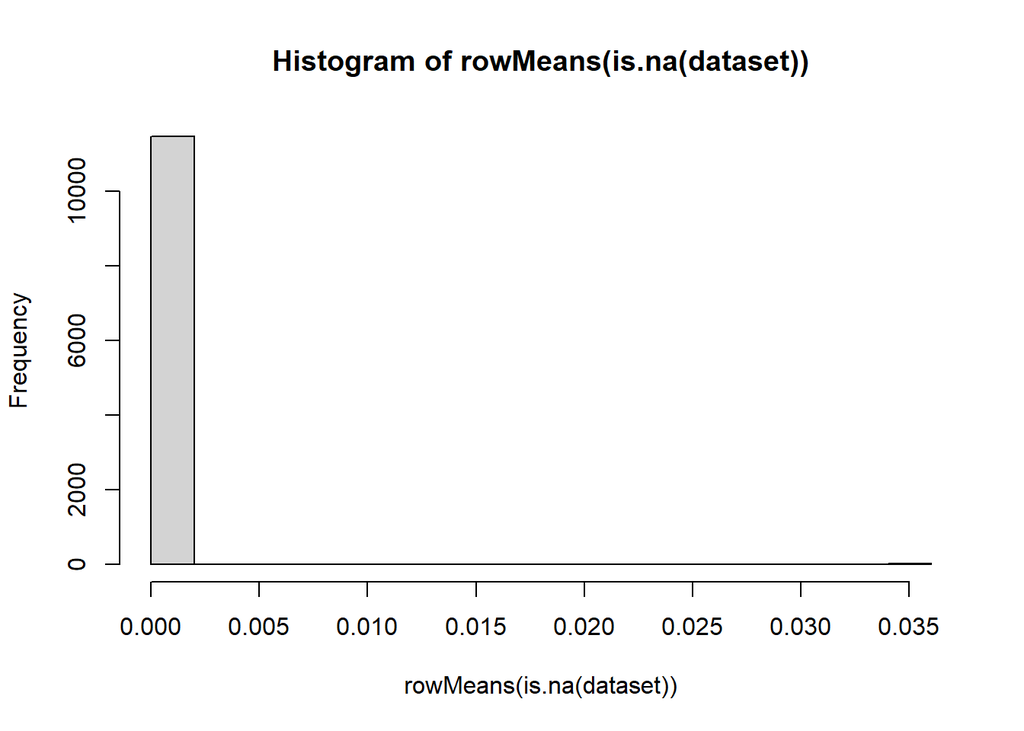

```r
hist(rowMeans(is.na(dataset)))
```

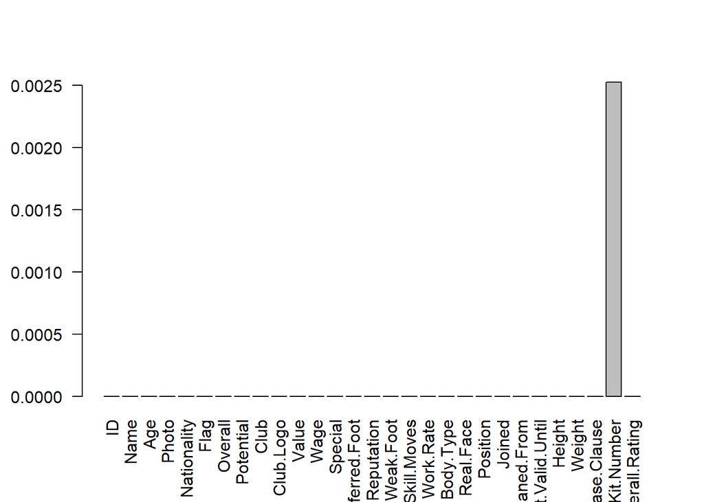

```r
barplot(colMeans(is.na(dataset)), las=2)
```

We see how many NA are in the data set by using the sum() and is.na() functions so we are going to use a if statement to see if there are NAs in the data set

```r
if (sum(is.na(dataset)) > 0){
  # Now, to be sure that this NAs values represent less than the 5% of the total data set
  # we create a if statement to verify this condition
  if (sum(is.na(dataset)/nrow(dataset)) < 0.05){
  # We change the data set to the same data set without NAs using the na.omit function
  # in the case there are NAs values
    dataset <- na.omit(dataset)
  }
}
```

There was NAs values so the data set has been modified

Let’s see if there are rows duplicated and remove them in the case there are, we are going to use the unique() function and use it just it case the number of rows of the data set with unique rows are not equal to the original data set. In this way it is not necessary to change again the whole data set, just in the case it is essential because there are duplicated rows.

```r
if (nrow(dataset) != nrow(unique(dataset))){
  dataset = unique(dataset)
}
```

As we can see, the condition for the if statement is not fulfilled so we can affirm there are no duplicated row

We will continue by removing useless variables that either will not be used during the whole work or we are not interesting

```r
dataset$Flag = NULL
dataset$Photo = NULL
dataset$Club.Logo = NULL
dataset$Loaned.From = NULL
dataset$Position = NULL
dataset$Best.Overall.Rating = NULL
dataset$Kit.Number = NULL
dataset$Body.Type = NULL
dataset$Special = NULL
dataset$ID = NULL
dataset$Joined = NULL
dataset$Contract.Valid.Until = NULL
```

I am going to modify most of the columns in order to change their classes to the class that I am interested in order to study them properly.

For the Real.Face variable I am going to change the variable, instead of “Yes” and “No”, I prefer to work with them as “TRUE” or “FALSE” (just for commodity). However, in order to apply supervised learning tools, I will keep this variable as character.

Because the Real.Face variable is a character variable, I will convert it into a factor by saying that if it is TRUE it means the face of the player is scanned into the video game, and if it is FALSE it means they did not scanned the face of the player into the FIFA 23.

```r
class(dataset$Real.Face) # Character
```

```
## [1] "character"
```

We are going to use a while loop to replace the “Yes” into TRUE and the “No” to FALSE (However, I am going to convert them into characters instead of boolean in order to have more categorical variables)

```r
i <- 1
while (i <= nrow(dataset)){
  if (dataset$Real.Face[i] == "Yes"){
    # In the case it is "Yes", then it is TRUE the player has his "real" face in the game
    dataset$Real.Face[i]<- "TRUE"
  }
  else{
    # If it is not "Yes", it must be "No"
    dataset$Real.Face[i]<- "FALSE"
  }
  i <- i + 1
}
dataset$Real.Face = as.character(dataset$Real.Face) # We finally set the whole variable as a categorical variable
```

Now we are going to change the values of the columns Value, Wage and Release.Clause in order to work with them, where I will convert them into numeric variables.

Let’s see which class are they right now:

```r
class(dataset$Value) # Character
```

```
## [1] "character"
```

```r
class(dataset$Wage) # Character
```

```
## [1] "character"
```

```r
class(dataset$Release.Clause) # Character
```

```
## [1] "character"
```

First of all, I need to delete the strings (the “â,¬” and the “K” or “M”) of the variables in order to convert them into numeric variables, in this case, there is a “â,¬” at the beginning and a “M” or “K” at the end, so I am going to use the functions substring() to make shorter the variable, and I am going to start from the forth character of the string to delete the 3 first that are the “â,¬” for the three variables.

```r
dataset$Value <- substring(dataset$Value, 4)
dataset$Wage <- substring(dataset$Wage, 4)
dataset$Release.Clause <- substring(dataset$Release.Clause, 4)
```

For the first loop (focused on the Wage variable, as we already deleted the “â,¬”, we need to take into account if the wage is paid in K or in units, so we are going to go through the different rows to know which ones ends with a K, that rows must be multiplied by 1000 and the K at the end must be deleted. Furthermore, I am going to use the function as.numeric() to make the numeric variables so it will be easier to work with them.

It is important to mention that any player earns more than 999K, so it is not necessary to create a case in which a player earns 1M or more. I will not create a case for a player that earns 1M or more because it will affect the efficiency and will require more computer resources, something that is completely unnecessary. Any ways, I added with # what would be the code in the case a players earn 1M or more. I also execute it and there was no difference between my current code or adding that piece of extra code.

```r
i <- 1
while (i <= nrow(dataset)){
  if (substring(dataset$Wage[i], nchar(dataset$Wage[i])) == "K"){
    # This statement is used to know if the wage is paid in K or in units,
    # that we can know this information by looking at the last character of the strings in this variable
    # we must multiply by 10^3 and also convert it to a numeric variable.
    dataset$Wage[i] <- 10^3 * as.numeric(substring(dataset$Wage[i], 1, nchar(dataset$Wage[i])-1))
  }
  #In the case we wanted to do it for a player that his wage is in millions (M)
  # we could use the following piece of code. I already use it just to be sure
  # the result is exactly the same, and it is verified that the data set have the
  # exactly same changes by using this case or not because any wage is paid in M.

  #if (substring(dataset$Wage[i], nchar(dataset$Wage[i])) == "M"){
  #dataset$Wage[i] <- 10^6 * as.numeric(substring(dataset$Wage[i], 1, nchar(dataset$Wage[i])-1))}

  else{
    # In the case it does not end with K, we just need to convert the variable into numeric
    dataset$Wage[i] <- as.numeric(dataset$Wage[i])
  # We continue the loop
  i <- i+1
  }
}
# We convert the whole column into a numeric variable
dataset$Wage = as.numeric(dataset$Wage)
```

We are going to do a similar process with the other 2 variables

For the Value variable, there are three possible cases, the first is the footballer costs 1 M or more, in where we need to multiply by 10^6. The second case is the player costs between 1 K and 999 K, in where we need to multiply by 10^3. Finally, the case where the player cost less than 1K, where we do not need to multiply by any number.  
It is also important to convert all the variables from characters to numeric.

```r
i <- 1
while (i <= nrow(dataset)){
  if (substring(dataset$Value[i], nchar(dataset$Value[i])) == "M"){
    # In the case the player cost 1M or more
    dataset$Value[i] <- 10^6 * as.numeric(substring(dataset$Value[i], 1, nchar(dataset$Value[i]) - 1))
    }
  if (substring(dataset$Value[i], nchar(dataset$Value[i])) == "K"){
    # In the case the player cost less than 1M
    dataset$Value[i] <- 10^3 * as.numeric(substring(dataset$Value[i], 1, nchar(dataset$Value[i]) - 1))
  }
  else{
    # In the case the players cost less than 1K, we just need to convert it to numeric
    dataset$Value[i] <- as.numeric(dataset$Value[i])
  }
  # To continue the loop
  i <- i + 1
  }

# We convert the whole variable to numeric
dataset$Value = as.numeric(dataset$Value)
```

Let’s do the same process for the Release.Clause variable

```r
i <- 1
while (i <= nrow(dataset)){
  if (substring(dataset$Release.Clause[i], nchar(dataset$Release.Clause[i])) == "M"){
    # In the case the release clause cost 1M or more
    dataset$Release.Clause[i] <- 10^6 * as.numeric(substring(dataset$Release.Clause[i], 1,
                                                             nchar(dataset$Release.Clause[i]) - 1))
  }
  if (substring(dataset$Release.Clause[i], nchar(dataset$Release.Clause[i])) == "K"){
    # In the case the release clause cost less than 1M
    dataset$Release.Clause[i] <- 10^3 * as.numeric(substring(dataset$Release.Clause[i], 1,
                                                             nchar(dataset$Release.Clause[i]) - 1))
  }
  else{
    # In the case the release clause cost less than 1K, we just need to convert it to numeric
    dataset$Release.Clause[i] <- as.numeric(dataset$Release.Clause[i])
  }
  # To continue the loop
  i <- i + 1
}
```

I noticed in this column that some release clauses converted from “nan” to NA, so I will change this NA values to other standard value in order to simplify the huge data set.

I had been thinking about possible solutions, one possible solution was to assign the value infinite (Inf) to all the elements which were NAs, however, after I started the machine learning process, I noticed that it brought a lot of issues and also for the visualization tools process it was quite complex.

```r
sum(is.na(dataset$Release.Clause)) # == sum(is.na(dataset))
```

```
## [1] 721
```

The reason why there is NA in some release clause is because there is no release clause, so if a team wants to buy the player,it must negotiate with his club first. They cannot pay a certain amount of money in order to purchase the footballer (the value of the release clause)

```r
i <- 1
while (i <= nrow(dataset)){
  if (is.na(dataset$Release.Clause[i]) == TRUE){
    # In the case it is an NA, I will use the mean to assign the mean of the
    # other values that are not NAs, in that way, I will avoid problems in the future
    # and maintain my data set clean and unnoisy.
    dataset$Release.Clause[i] = as.numeric(mean(as.numeric(dataset$Release.Clause), na.rm = TRUE))
  }
  i = i + 1
}
dataset$Release.Clause = as.numeric(dataset$Release.Clause)
```

The Age and Potential should be treated as numeric variables.

```r
dataset$Age = as.numeric(dataset$Age)
dataset$Potential = as.numeric(dataset$Potential)
dataset$Overall = as.numeric(dataset$Overall)
```

Lets check for rest of the variables

```r
class(dataset$Weak.Foot) # Numeric, so it is not necessary to change the class of the variable
```

```
## [1] "numeric"
```

```r
class(dataset$Skill.Moves) # Numeric, same as Weak.Foot variable
```

```
## [1] "numeric"
```

Convert some variables into characters

```r
dataset$Nationality = as.character(dataset$Nationality)
dataset$Work.Rate = as.character(dataset$Work.Rate)
dataset$Preferred.Foot = as.character(dataset$Preferred.Foot)

# In the case of the international reputation I will consider it as a numeric
dataset$International.Reputation = as.numeric(dataset$International.Reputation)
```

For the height variable we are going to convert it to a numeric variable

```r
i <- 1
while (i <= nrow(dataset)){
  # I use the function nchar() and substring() to choose from the first letter
  # to the ante penultimate letter (to avoid choosing the "cm" part)
  dataset$Height[i] <- as.numeric(substring(dataset$Height[i], 1, nchar(dataset$Height[i])-2))
  i = i + 1
}
dataset$Height = as.numeric(dataset$Height)
```

Exactly the same for the weightF

```r
i <- 1
while (i <= nrow(dataset)){
  # I use the function nchar() and substring() to choose from the first letter
  # to the ante penultimate letter (to avoid choosing the "kg" part)
  dataset$Weight[i] <- as.numeric(substring(dataset$Weight[i], 1, nchar(dataset$Weight[i])-2))
  i = i + 1
}
dataset$Weight = as.numeric(dataset$Weight)
```

A quick view of what we already have

```r
View(dataset)
summary(dataset)
```

```
##      Name                Age       Nationality           Overall
##  Length:11451       Min.   :16.0   Length:11451       Min.   :44.00
##  Class :character   1st Qu.:20.0   Class :character   1st Qu.:58.00
##  Mode  :character   Median :22.0   Mode  :character   Median :63.00
##                     Mean   :23.1                      Mean   :63.35
##                     3rd Qu.:26.0                      3rd Qu.:69.00
##                     Max.   :44.0                      Max.   :91.00
##    Potential         Club               Value                Wage
##  Min.   :47.00   Length:11451       Min.   :        0   Min.   :     0
##  1st Qu.:67.00   Class :character   1st Qu.:   325000   1st Qu.:   550
##  Median :71.00   Mode  :character   Median :   700000   Median :  2000
##  Mean   :70.99                      Mean   :  2751054   Mean   :  8171
##  3rd Qu.:75.00                      3rd Qu.:  1800000   3rd Qu.:  5000
##  Max.   :95.00                      Max.   :190500000   Max.   :450000
##  Preferred.Foot     International.Reputation   Weak.Foot      Skill.Moves
##  Length:11451       Min.   :1.000            Min.   :1.000   Min.   :1.000
##  Class :character   1st Qu.:1.000            1st Qu.:3.000   1st Qu.:2.000
##  Mode  :character   Median :1.000            Median :3.000   Median :2.000
##                     Mean   :1.105            Mean   :2.902   Mean   :2.301
##                     3rd Qu.:1.000            3rd Qu.:3.000   3rd Qu.:3.000
##                     Max.   :5.000            Max.   :5.000   Max.   :5.000
##   Work.Rate          Real.Face             Height          Weight
##  Length:11451       Length:11451       Min.   :149.0   Min.   : 48.00
##  Class :character   Class :character   1st Qu.:176.0   1st Qu.: 70.00
##  Mode  :character   Mode  :character   Median :180.0   Median : 74.00
##                                        Mean   :180.8   Mean   : 74.28
##                                        3rd Qu.:186.0   3rd Qu.: 79.00
##                                        Max.   :206.0   Max.   :110.00
##  Release.Clause
##  Min.   :    20000
##  1st Qu.:   642000
##  Median :  1500000
##  Mean   :  5378693
##  3rd Qu.:  4400000
##  Max.   :366700000
```

```r
str(dataset)
```

```
## 'data.frame':    11451 obs. of  17 variables:
##  $ Name                    : chr  "M. AcuÃ±a" "K. De Bruyne" "N. Barella" "D. Alaba" ...
##  $ Age                     : num  30 31 25 30 32 28 26 36 26 28 ...
##  $ Nationality             : chr  "Argentina" "Belgium" "Italy" "Austria" ...
##  $ Overall                 : num  85 91 86 86 83 88 84 88 83 84 ...
##  $ Potential               : num  85 91 89 86 83 88 87 88 86 84 ...
##  $ Club                    : chr  "Sevilla FC" "Manchester City" "Inter" "Real Madrid CF" ...
##  $ Value                   : num  4.65e+07 1.08e+08 8.95e+07 5.55e+07 2.85e+07 ...
##  $ Wage                    : num  46000 350000 110000 220000 61000 250000 95000 230000 49000 85000 ...
##  $ Preferred.Foot          : chr  "Left" "Right" "Right" "Left" ...
##  $ International.Reputation: num  2 4 3 4 3 3 2 4 1 1 ...
##  $ Weak.Foot               : num  3 5 3 4 4 4 4 4 3 3 ...
##  $ Skill.Moves             : num  3 4 3 3 4 4 3 4 3 4 ...
##  $ Work.Rate               : chr  "High/ High" "High/ High" "High/ High" "Medium/ Medium" ...
##  $ Real.Face               : chr  "FALSE" "TRUE" "TRUE" "TRUE" ...
##  $ Height                  : num  172 181 172 180 183 182 186 172 189 180 ...
##  $ Weight                  : num  69 70 68 78 80 74 77 66 83 70 ...
##  $ Release.Clause          : num  9.77e+07 1.99e+08 1.54e+08 1.14e+08 4.85e+07 ...
##  - attr(*, "na.action")= 'omit' Named int [1:29] 444 590 1680 3294 4156 4623 5014 5134 5166 5175 ...
##   ..- attr(*, "names")= chr [1:29] "683" "909" "2595" "5032" ...
```

Now, lets split the data set into train and test data sets in order to work with them.

```r
# split between training and testing sets
spl = createDataPartition(dataset$Overall, p = 0.8, list = FALSE)  # 80% for training

datasetTrain = dataset[spl,]
datasetTest = dataset[-spl,]

str(datasetTrain)
```

```
## 'data.frame':    9162 obs. of  17 variables:
##  $ Name                    : chr  "M. AcuÃ±a" "K. De Bruyne" "N. Barella" "D. Alaba" ...
##  $ Age                     : num  30 31 25 30 28 36 26 25 34 29 ...
##  $ Nationality             : chr  "Argentina" "Belgium" "Italy" "Austria" ...
##  $ Overall                 : num  85 91 86 86 88 88 83 87 83 85 ...
##  $ Potential               : num  85 91 89 86 88 88 86 92 83 85 ...
##  $ Club                    : chr  "Sevilla FC" "Manchester City" "Inter" "Real Madrid CF" ...
##  $ Value                   : num  4.65e+07 1.08e+08 8.95e+07 5.55e+07 8.25e+07 ...
##  $ Wage                    : num  46000 350000 110000 220000 250000 230000 49000 230000 120000 56000 ...
##  $ Preferred.Foot          : chr  "Left" "Right" "Right" "Left" ...
##  $ International.Reputation: num  2 4 3 4 3 4 1 3 3 3 ...
##  $ Weak.Foot               : num  3 5 3 4 4 4 3 3 3 2 ...
##  $ Skill.Moves             : num  3 4 3 3 4 4 3 4 5 3 ...
##  $ Work.Rate               : chr  "High/ High" "High/ High" "High/ High" "Medium/ Medium" ...
##  $ Real.Face               : chr  "FALSE" "TRUE" "TRUE" "TRUE" ...
##  $ Height                  : num  172 181 172 180 182 172 189 180 179 184 ...
##  $ Weight                  : num  69 70 68 78 74 66 83 74 72 84 ...
##  $ Release.Clause          : num  9.77e+07 1.99e+08 1.54e+08 1.14e+08 1.53e+08 ...
##  - attr(*, "na.action")= 'omit' Named int [1:29] 444 590 1680 3294 4156 4623 5014 5134 5166 5175 ...
##   ..- attr(*, "names")= chr [1:29] "683" "909" "2595" "5032" ...
```

```r
summary(datasetTrain)
```

```
##      Name                Age        Nationality           Overall
##  Length:9162        Min.   :16.00   Length:9162        Min.   :44.00
##  Class :character   1st Qu.:20.00   Class :character   1st Qu.:58.00
##  Mode  :character   Median :22.00   Mode  :character   Median :63.00
##                     Mean   :23.09                      Mean   :63.33
##                     3rd Qu.:26.00                      3rd Qu.:69.00
##                     Max.   :44.00                      Max.   :91.00
##    Potential         Club               Value                Wage
##  Min.   :47.00   Length:9162        Min.   :        0   Min.   :     0
##  1st Qu.:67.00   Class :character   1st Qu.:   325000   1st Qu.:   550
##  Median :71.00   Mode  :character   Median :   700000   Median :  2000
##  Mean   :70.99                      Mean   :  2783552   Mean   :  8150
##  3rd Qu.:75.00                      3rd Qu.:  1800000   3rd Qu.:  6000
##  Max.   :95.00                      Max.   :190500000   Max.   :350000
##  Preferred.Foot     International.Reputation   Weak.Foot      Skill.Moves
##  Length:9162        Min.   :1.000            Min.   :1.000   Min.   :1.000
##  Class :character   1st Qu.:1.000            1st Qu.:3.000   1st Qu.:2.000
##  Mode  :character   Median :1.000            Median :3.000   Median :2.000
##                     Mean   :1.102            Mean   :2.904   Mean   :2.305
##                     3rd Qu.:1.000            3rd Qu.:3.000   3rd Qu.:3.000
##                     Max.   :5.000            Max.   :5.000   Max.   :5.000
##   Work.Rate          Real.Face             Height          Weight
##  Length:9162        Length:9162        Min.   :155.0   Min.   : 48.00
##  Class :character   Class :character   1st Qu.:176.0   1st Qu.: 70.00
##  Mode  :character   Mode  :character   Median :180.0   Median : 74.00
##                                        Mean   :180.8   Mean   : 74.26
##                                        3rd Qu.:185.0   3rd Qu.: 79.00
##                                        Max.   :206.0   Max.   :110.00
##  Release.Clause
##  Min.   :    20000
##  1st Qu.:   646000
##  Median :  1450000
##  Mean   :  5434226
##  3rd Qu.:  4400000
##  Max.   :366700000
```

# Studying & transforming a numerical variable into a categorical

In order to study classification, we must study one categorical variable, so instead of choosing one of my categorical variables (which I consider none of them are enough interesting in order to study it), I will choose one numerical variable and transform it into a categorical one, to do that, I will analyze some of my numerical variables and decide which will be my main categorical variable. Because I would like to predict which are the best players, I consider one quite interesting variable could be the Overall, which I consider it is quite interesting to study as a categorical (specially if we can divide it in categories). But firstly, lets see its correlation with the rest of the variables

## Visualization of the variable

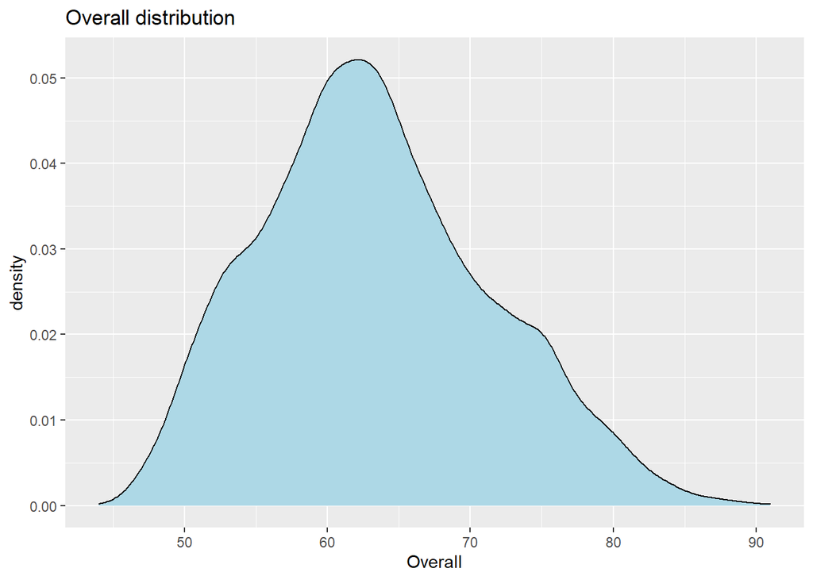

```r
ggplot(datasetTrain, aes(Overall)) + geom_density(fill="lightblue") +
  xlab("Overall") + ggtitle("Overall distribution")
```

We can see clearly a distribution similar to a normal distribution

```r
median(datasetTrain$Overall)
```

```
## [1] 63
```

```r
mean(datasetTrain$Overall)
```

```
## [1] 63.33279
```

Lets compare it with another important variables such as the International reputation

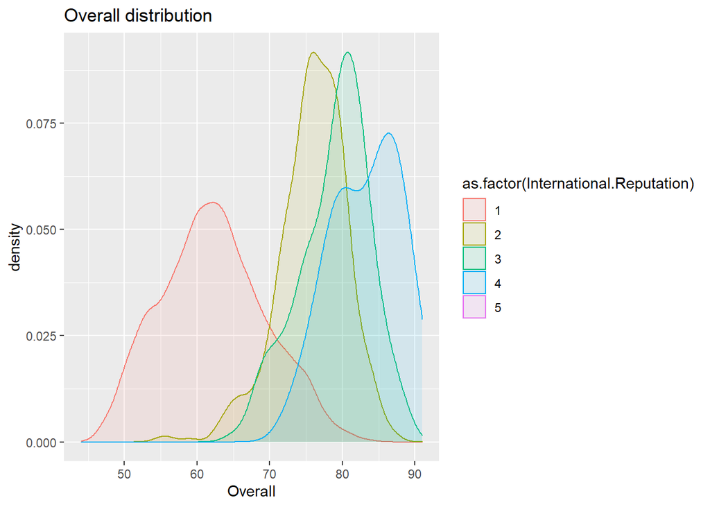

```r
ggplot(datasetTrain, aes(Overall)) + geom_density(aes(group=as.factor(International.Reputation), colour=as.factor(International.Reputation), fill=as.factor(International.Reputation)), alpha=0.1) +
  ggtitle("Overall distribution")
```

Lets see it with the skill moves and the weak foot variables

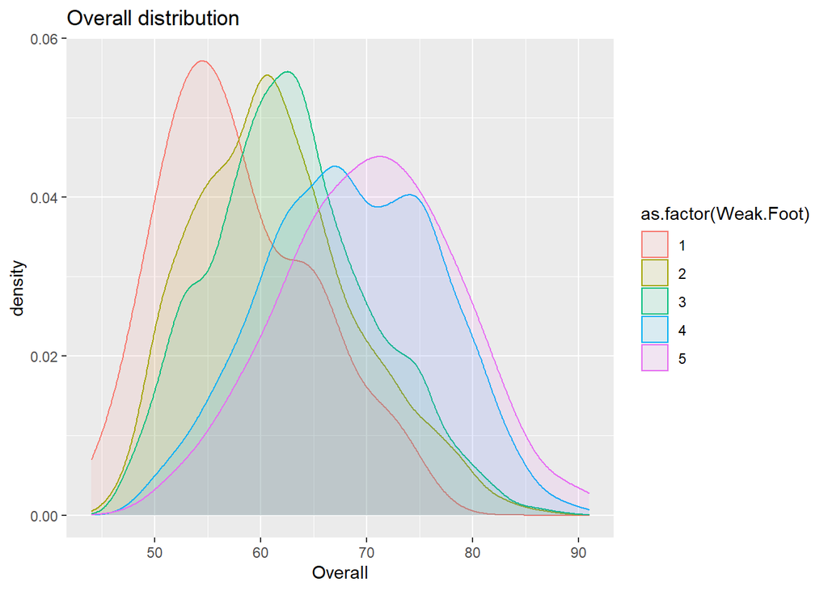

```r
ggplot(datasetTrain, aes(Overall)) + geom_density(aes(group=as.factor(Weak.Foot), colour=as.factor(Weak.Foot), fill=as.factor(Weak.Foot)), alpha=0.1) +
  ggtitle("Overall distribution")
```

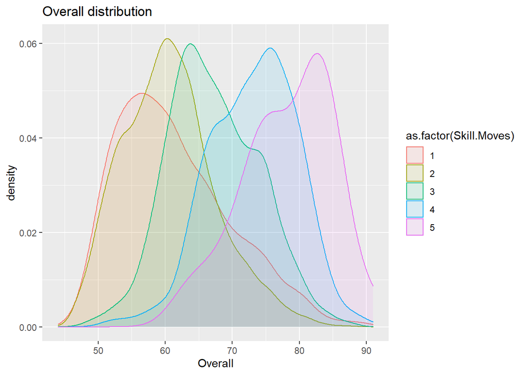

```r
ggplot(datasetTrain, aes(Overall)) + geom_density(aes(group=as.factor(Skill.Moves), colour=as.factor(Skill.Moves), fill=as.factor(Skill.Moves)), alpha=0.1) +
  ggtitle("Overall distribution")
```

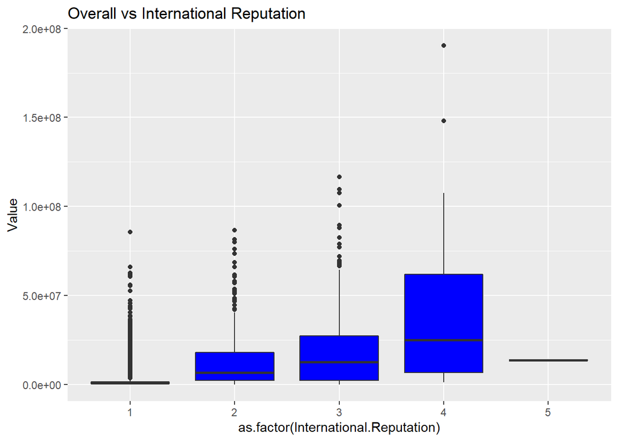

```r
ggplot(datasetTrain, aes(x=as.factor(International.Reputation), y=Value)) + geom_boxplot(fill="blue") +
  ggtitle("Overall vs International Reputation")
```

We are going to create an auxiliar variable which will be equal to the dataset but with just the numerical variables and scaled in order to use the function featurePlot()

```r
numericalTrain_dataset = datasetTrain

numericalTrain_dataset$Name = NULL
numericalTrain_dataset$Nationality = NULL
numericalTrain_dataset$Preferred.Foot = NULL
numericalTrain_dataset$Work.Rate = NULL
numericalTrain_dataset$Real.Face = NULL
numericalTrain_dataset$Club = NULL
```

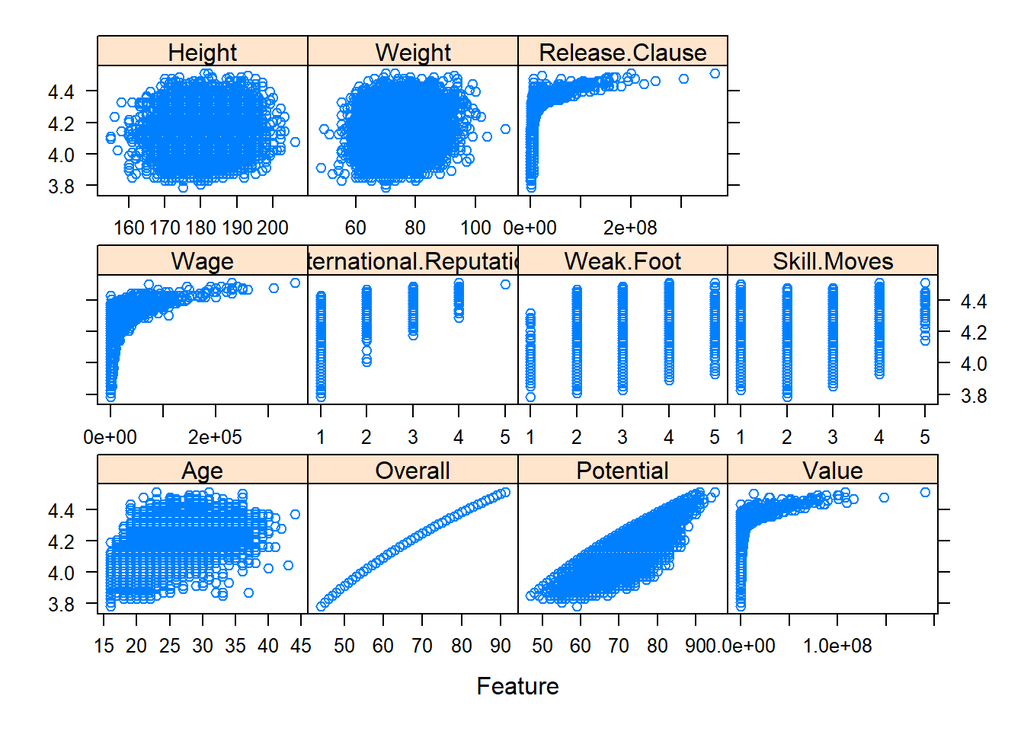

```r
featurePlot(x = numericalTrain_dataset[, c(1:11)],
            y = log(datasetTrain$Overall),
            plot = "scatter")
```

We can see some correlations with variables such as potential or wage, but there are plenty of variables which are not correlated such as height or weight. Also, later I will use the ggcorr() in order to prove the data set is not very correlated. For that reason the correlated variables with overall will be remove it later on

## Correlation with my studied variable

Lets see which are the variables most correlated to Overall

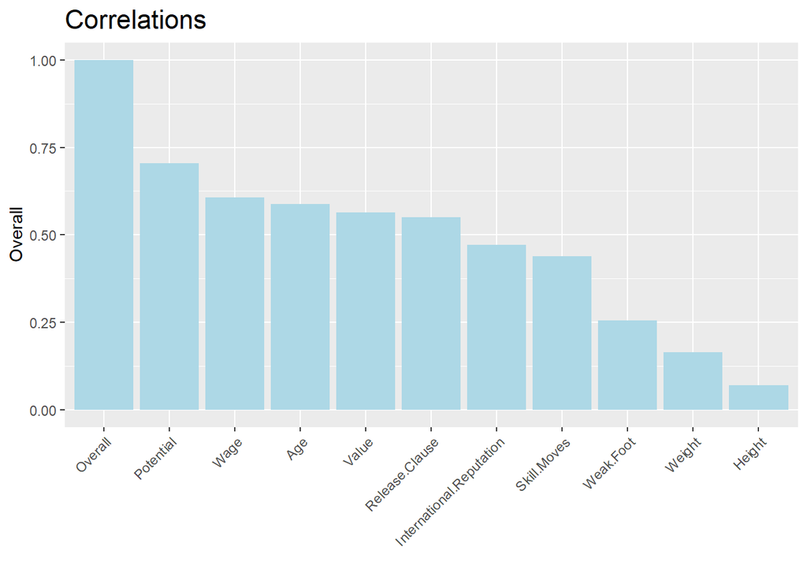

```r
corr_overall = sort(cor(numericalTrain_dataset[,c(1:11)])["Overall",], decreasing = T)
corr=data.frame(corr_overall)
ggplot(corr,aes(x = row.names(corr), y = corr_overall)) +
  geom_bar(stat = "identity", fill = "lightblue") +
  scale_x_discrete(limits= row.names(corr)) +
  labs(x = "", y = "Overall", title = "Correlations") +
  theme(plot.title = element_text(hjust = 0, size = rel(1.5)),
        axis.text.x = element_text(angle = 45, hjust = 1))
```

I have decided to delete the variable Potential because as we can see, it is highly correlated with the variable overall.

```r
dataset$Potential = NULL
```

```r
linFit <- lm(Overall ~ International.Reputation, data=datasetTrain)
summary(linFit)
```

```
##
## Call:
## lm(formula = Overall ~ International.Reputation, data = datasetTrain)
##
## Residuals:
##      Min       1Q   Median       3Q      Max
## -18.3548  -5.3548  -0.3548   4.6452  21.6452
##
## Coefficients:
##                          Estimate Std. Error t value Pr(>|t|)
## (Intercept)               52.7716     0.2198  240.09   <2e-16 ***
## International.Reputation   9.5832     0.1878   51.04   <2e-16 ***
## ---
## Signif. codes:  0 '***' 0.001 '**' 0.01 '*' 0.05 '.' 0.1 ' ' 1
##
## Residual standard error: 7.094 on 9160 degrees of freedom
## Multiple R-squared:  0.2214, Adjusted R-squared:  0.2213
## F-statistic:  2605 on 1 and 9160 DF,  p-value: < 2.2e-16
```

```r
predictions <- exp(predict(linFit, newdata=datasetTest))-10
cor(datasetTest$Overall, predictions)^2
```

```
## [1] 0.009413689
```

Probably we could justify that the test set is less than the R^2 in the training set because it is a worst model (probably due to the fewer amount of data in the test set)

We could apply multiple regression, however, it is too PC-resource demanding, so I will just write in with # just to show how it should be applied

```r
#linFit <- lm(Overall ~ ., data=datasetTrain)
#summary(linFit)

# And to make the prediction using a multiple regression model

#pred.log <- predict(linFit, newdata=datasetTest)
#cor(datasetTest$Overall, pred.log)^2
```

## Classification approach

I consider it is good to use this three categories because we will predict players in the 3 categories already existing in the game (bronze, silver and gold) that would make sense in my classification topic and will be according to the game rules, which at the end of the day is what my data set is based.

Before all, lets see how many players are in each category

```r
# Let's see if the categories are more or less balanced
# We start with the players that are in the category of bronze
i <- 1
b = 0
while (i <= nrow(dataset)){
  if (dataset$Overall[i] <= 59 ){
    b = b+1
  }
  i = i+1
  }
b
```

```
## [1] 3810
```

```r
# Players in the silver category
i <- 1
s = 0
while (i <= nrow(dataset)){
  if (dataset$Overall[i] > 59 && dataset$Overall[i] < 67 ){
    s = s+1
  }
  i = i+1
  }
s
```

```
## [1] 3932
```

```r
# Players higher than 70 which belongs to the gold category
i <- 1
g = 0
while (i <= nrow(dataset)){
  if (dataset$Overall[i] >= 67 ){
    g = g+1
  }
  i = i+1
  }
g
```

```
## [1] 3709
```

```r
# In order to check that we selected all the rows, we can verify it by comparing the number of rows of the data set and the sum of the number of gold, silver and bronze players (which should be the same)
(g + b + s) == nrow(dataset) #TRUE
```

```
## [1] TRUE
```

As we can see, we include all the players in one of the three existing categories and we also obtained more or less balanced groups in terms of the number of data in each category, which I consider it is good. However, it is true that the class “gold” is a little bit unbalanced compared to the other two classes, however, it makes sense in this context because there must be less top players than average or bad players.

I will create an auxiliary variable called dataset_2c in order to save my data set with the variable Overall in numerical terms, because I will need in the future in order to instead of working with 3 classes in my categorical main variable, I will work with 2 classes (I will later explain it), in this way we could apply more methods of supervised learning tools.

I will create a dataset that I will use it in the future in order to apply binary classification methods

```r
# dataset for binary classification
dataset_2c = dataset
```

Lets now make the swap.

```r
dataset$Type = factor(ifelse(dataset$Overall < 60, "Bronze", ifelse(dataset$Overall >= 67, "Gold", "Silver")))

# We must delete the Overall class
dataset$Overall = NULL
```

In this way we change from a numerical variable to a categorical variable (in which the levels are Gold, Silver and Bronze).

```r
levels(dataset$Type)
```

```
## [1] "Bronze" "Gold"   "Silver"
```

```r
table(dataset$Type)
```

```
##
## Bronze   Gold Silver
##   3810   3709   3932
```

As before, classes are very balanced.

# Outliers

I am going to plot different box plots in order to identify the outliers and after I will decide if it is necessary to delete them or not depending if they make sense inside the data set

As we can see in the following box plots, there is a huge amount of outliers, specially in the Wage, Release.Clause and Value variables, however, it make sense that especifically in those variables there are an important amount of outliers, because there is quite few top professional footballers that earns so much money or have that value in the market. About the rest of the variables (such as height or weight), we can see there exist some outliers but quite less than other variables. But as before, it is normal to see a big difference of height for example between footballers but is something natural and common.

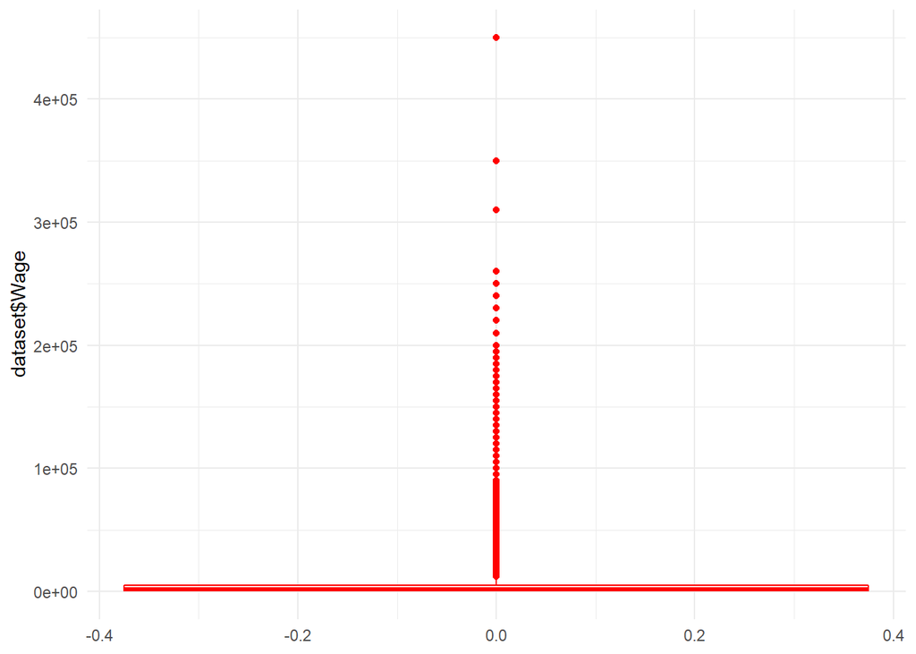

```r
ggplot(dataset, aes(y = dataset$Wage)) + geom_boxplot(color = "red") + theme_minimal()
```

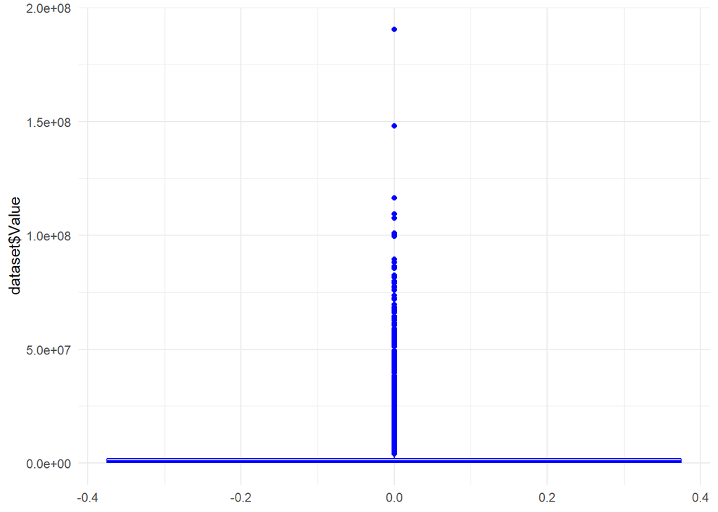

```r
ggplot(dataset, aes(y = dataset$Value)) + geom_boxplot(color = "blue") + theme_minimal()
```

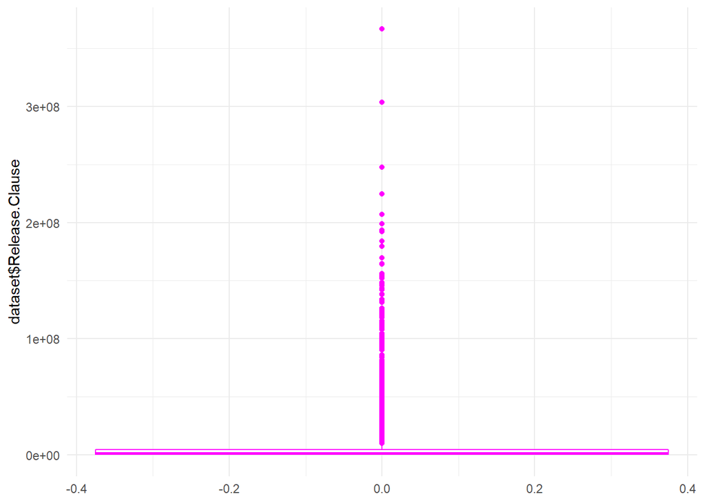

```r
ggplot(dataset, aes(y = dataset$Release.Clause)) + geom_boxplot(color = "magenta") + theme_minimal()
```

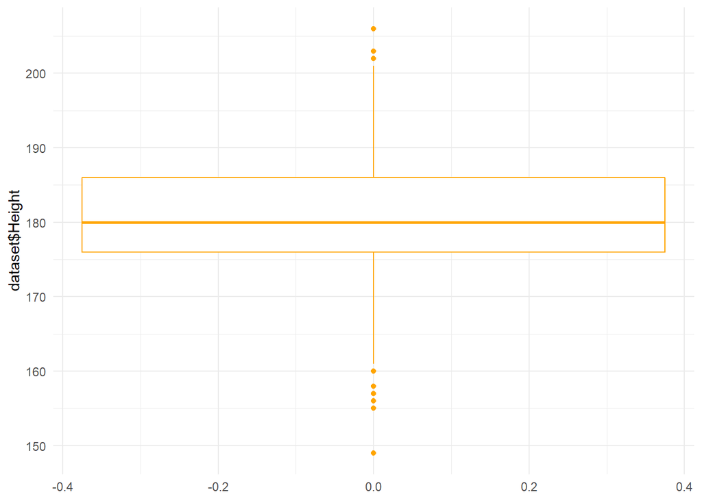

```r
ggplot(dataset, aes(y = dataset$Height)) + geom_boxplot(color = "orange") + theme_minimal()
```

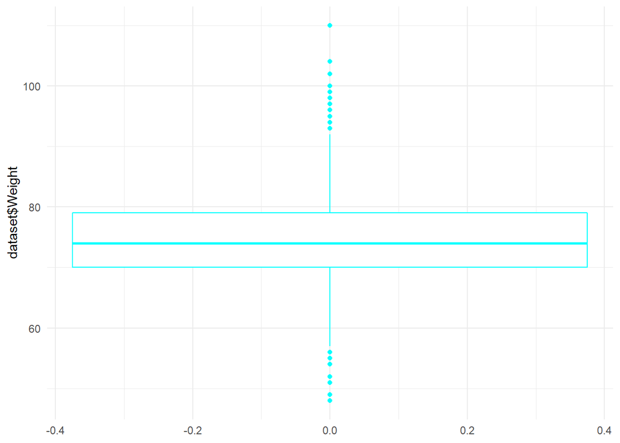

```r
ggplot(dataset, aes(y = dataset$Weight)) + geom_boxplot(color = "cyan") + theme_minimal()
```

After considering different possibilities, I think the best option is leave the outliers because all of them makes sense and do not contribute noise to the data set. The reason of all this amount of outliers is because the best players in the video game have a value, wage, etc… quite higher than the mean footballer in FIFA 23. It is not surprising to see it because that players are quite famous so they move a lot of money around them. However, almost any non top footballer have a wage, value and release clause quite small compared to the elite, which is conformed by just a few, that is why they are the outliers.

We finally obtained the following data set after the whole pre-processing previously done.

```r
categorical_dataset = dataset
View(dataset)
summary(dataset)
```

```
##      Name                Age       Nationality            Club
##  Length:11451       Min.   :16.0   Length:11451       Length:11451
##  Class :character   1st Qu.:20.0   Class :character   Class :character
##  Mode  :character   Median :22.0   Mode  :character   Mode  :character
##                     Mean   :23.1
##                     3rd Qu.:26.0
##                     Max.   :44.0
##      Value                Wage        Preferred.Foot
##  Min.   :        0   Min.   :     0   Length:11451
##  1st Qu.:   325000   1st Qu.:   550   Class :character
##  Median :   700000   Median :  2000   Mode  :character
##  Mean   :  2751054   Mean   :  8171
##  3rd Qu.:  1800000   3rd Qu.:  5000
##  Max.   :190500000   Max.   :450000
##  International.Reputation   Weak.Foot      Skill.Moves     Work.Rate
##  Min.   :1.000            Min.   :1.000   Min.   :1.000   Length:11451
##  1st Qu.:1.000            1st Qu.:3.000   1st Qu.:2.000   Class :character
##  Median :1.000            Median :3.000   Median :2.000   Mode  :character
##  Mean   :1.105            Mean   :2.902   Mean   :2.301
##  3rd Qu.:1.000            3rd Qu.:3.000   3rd Qu.:3.000
##  Max.   :5.000            Max.   :5.000   Max.   :5.000
##   Real.Face             Height          Weight       Release.Clause
##  Length:11451       Min.   :149.0   Min.   : 48.00   Min.   :    20000
##  Class :character   1st Qu.:176.0   1st Qu.: 70.00   1st Qu.:   642000
##  Mode  :character   Median :180.0   Median : 74.00   Median :  1500000
##                     Mean   :180.8   Mean   : 74.28   Mean   :  5378693
##                     3rd Qu.:186.0   3rd Qu.: 79.00   3rd Qu.:  4400000
##                     Max.   :206.0   Max.   :110.00   Max.   :366700000
##      Type
##  Bronze:3810
##  Gold  :3709
##  Silver:3932
##
##
##
```

```r
str(dataset)
```

```
## 'data.frame':    11451 obs. of  16 variables:
##  $ Name                    : chr  "M. AcuÃ±a" "K. De Bruyne" "N. Barella" "D. Alaba" ...
##  $ Age                     : num  30 31 25 30 32 28 26 36 26 28 ...
##  $ Nationality             : chr  "Argentina" "Belgium" "Italy" "Austria" ...
##  $ Club                    : chr  "Sevilla FC" "Manchester City" "Inter" "Real Madrid CF" ...
##  $ Value                   : num  4.65e+07 1.08e+08 8.95e+07 5.55e+07 2.85e+07 ...
##  $ Wage                    : num  46000 350000 110000 220000 61000 250000 95000 230000 49000 85000 ...
##  $ Preferred.Foot          : chr  "Left" "Right" "Right" "Left" ...
##  $ International.Reputation: num  2 4 3 4 3 3 2 4 1 1 ...
##  $ Weak.Foot               : num  3 5 3 4 4 4 4 4 3 3 ...
##  $ Skill.Moves             : num  3 4 3 3 4 4 3 4 3 4 ...
##  $ Work.Rate               : chr  "High/ High" "High/ High" "High/ High" "Medium/ Medium" ...
##  $ Real.Face               : chr  "FALSE" "TRUE" "TRUE" "TRUE" ...
##  $ Height                  : num  172 181 172 180 183 182 186 172 189 180 ...
##  $ Weight                  : num  69 70 68 78 80 74 77 66 83 70 ...
##  $ Release.Clause          : num  9.77e+07 1.99e+08 1.54e+08 1.14e+08 4.85e+07 ...
##  $ Type                    : Factor w/ 3 levels "Bronze","Gold",..: 2 2 2 2 2 2 2 2 2 2 ...
##  - attr(*, "na.action")= 'omit' Named int [1:29] 444 590 1680 3294 4156 4623 5014 5134 5166 5175 ...
##   ..- attr(*, "names")= chr [1:29] "683" "909" "2595" "5032" ...
```

## Correlation between variables

Before the visualization tools, we could start by watching the relation between the variables in order to study them and prove that the data set is not very correlated and also to know which of the variables are the most correlated to use it for the visualization tools in order to obtain interesting conclusions

```r
library(factoextra)
library(GGally)
```

Lets create a new varialbe which contains only the numerical variables and already scaled, and we will use the ggcorr() in order to have a graphical representation of the correlation between variables

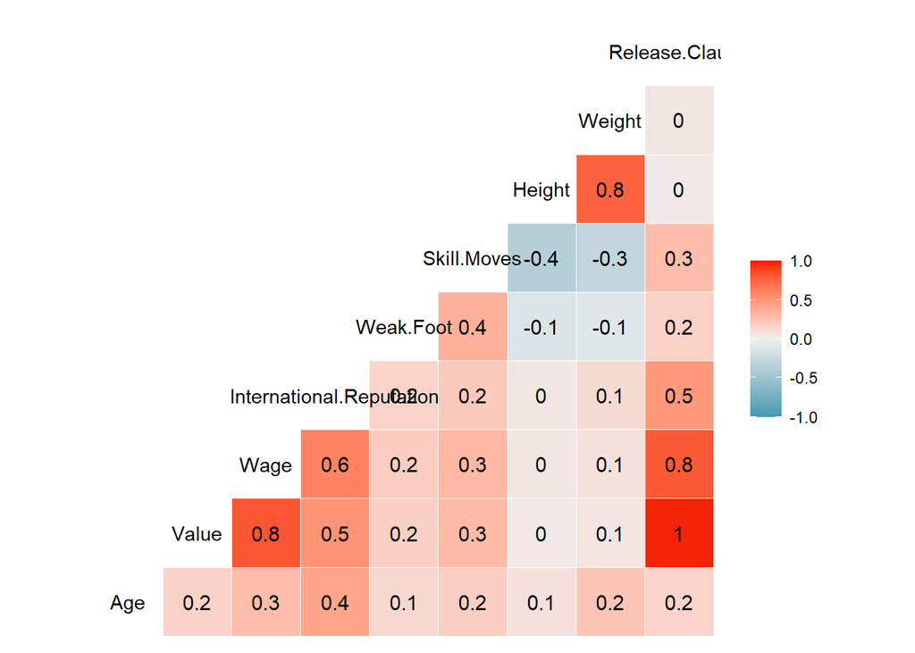

```r
numerical_dataset = dataset

numerical_dataset$Name = NULL
numerical_dataset$Nationality = NULL
numerical_dataset$Preferred.Foot = NULL
numerical_dataset$Work.Rate = NULL
numerical_dataset$Real.Face = NULL
numerical_dataset$Club = NULL
numerical_dataset$Type = NULL

numerical_dataset = scale(numerical_dataset)

ggcorr(numerical_dataset, label = T)
```

As we can see there are 29 correlations between -0.4 and 0.4, and the rest (which are greater or equal than 0.5 or lower or equal to -0.5) are 7 correlations, so we could say the data set is not very correlated, however, we have some correlated variables which will also be useful.

# Visualization Tools

## Univariable

First of all, we will graph some of the variables individually

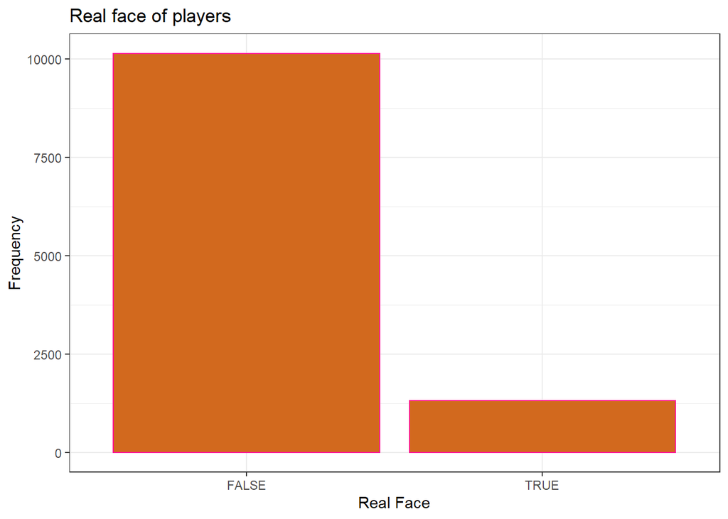

```r
ggplot(dataset, aes(dataset$Real.Face)) + geom_bar(color = "deeppink", fill = "chocolate") + labs(title = "Real face of players",
                                                            x = "Real Face", y = "Frequency") + theme_bw()
```

[figure not shown]

```r
ggplot(dataset, aes(dataset$Height)) + geom_histogram(color = "chartreuse 3", fill = "chartreuse", binwidth = 3) +
  labs(x = "Potential (Points out of 100)", y = "Frequency") + theme_grey()
```

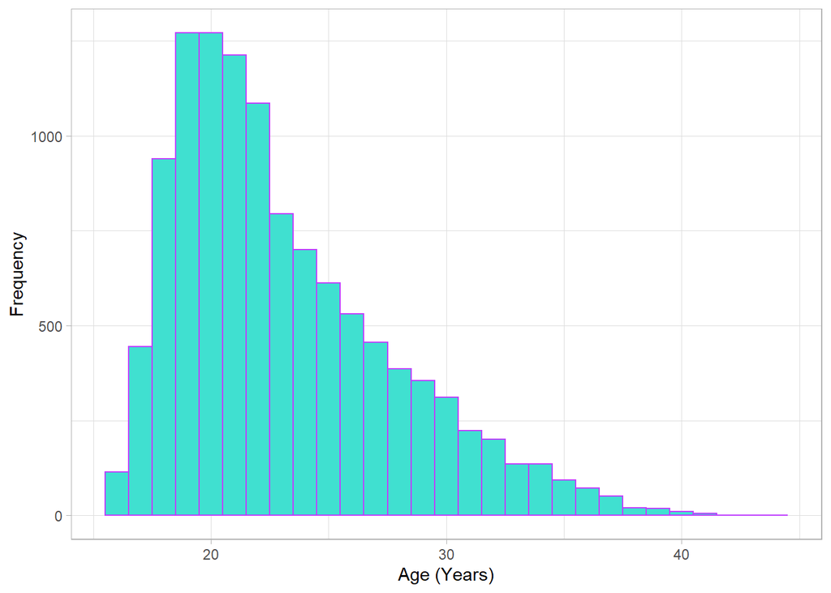

```r
ggplot(dataset, aes(dataset$Age)) +
  geom_histogram(color = "darkorchid1", fill = "turquoise", binwidth = 1) +
  labs(x = "Age (Years)", y = "Frequency") + theme_light() + scale_x_continuous()
```

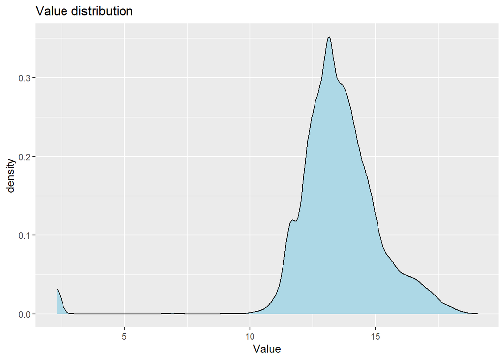

```r
ggplot(dataset, aes(log(dataset$Value+10))) + geom_density(fill="lightblue") +
  xlab("Value") + ggtitle("Value distribution") + scale_x_continuous()
```

## Bivariable

Lets now explore our data relations and see graphically their relation between the variables.

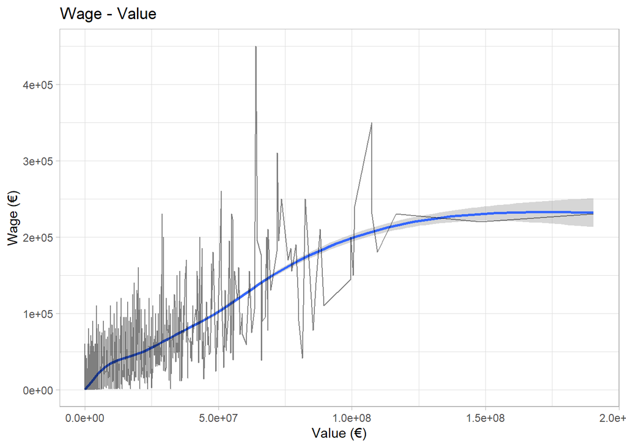

```r
ggplot(dataset, aes(dataset$Value, dataset$Wage)) + geom_smooth(method = "gam",
                                                                  formula = y ~ s(x, bs = "cs"))+
  geom_line(alpha = 0.5) + theme_light() + labs(title= "Wage - Value",
                                                x = "Value (€)", y = "Wage (€)")
```

Also we can compare between the international reputation of a player and his value in the market, because we can suppose that a player will have a bigger value depending in variables such as value, or in this case, his international reputation

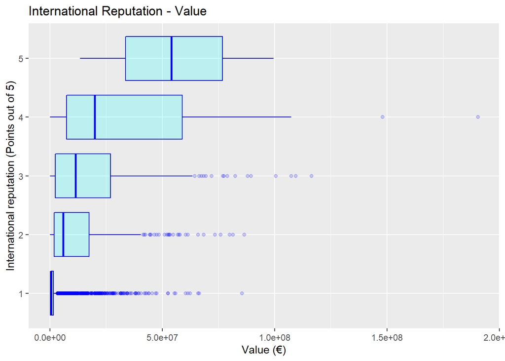

```r
ggplot(dataset, aes(y = as.factor(dataset$International.Reputation), x = dataset$Value)) + geom_boxplot(color = "blue", fill = "cyan", alpha = 0.2) +
  theme_get() + labs(title = "International Reputation - Value",
                     y = "International reputation (Points out of 5)", x = "Value (€)")
```

We could also search another relation between the age and the skill moves, because when a player is younger, usually will be more agile and for that reason, maybe their skill moves will be better.

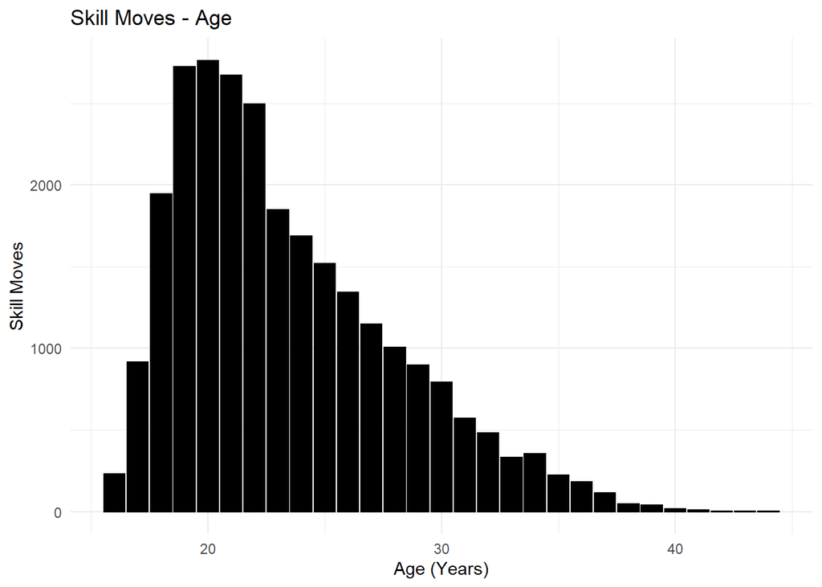

```r
ggplot(dataset, aes(dataset$Age, dataset$Skill.Moves)) + geom_col(color = "black", alpha = 0.5, linetype = 1) +
  theme_minimal() + labs(y = "Skill Moves",
                         x = "Age (Years)", title = "Skill Moves - Age")
```

As we supposed, when the footballers are older, their skill moves are worst, specially players between 20 and 25 years are the ones with the best skill moves, which makes sense because they are in the prime or their career.

[figure not shown]

```r
ggplot(dataset, aes(as.factor(dataset$Real.Face), dataset$Value)) + geom_boxplot(color = "purple",
                                                                        fill = "lightblue", alpha = 0.5) +
  geom_violin(alpha = 0.01) + theme_light() + labs(title = "Overall - Real.Face",
                                                   x = "Real Face included",
                                                   y = "Potential (Points out of 100)") + scale_alpha()
```

After plotting the box plot and the violin plot, we can see that is quite likely that if the footballer have a high market value, his face will probably be included in the video game. It can be also justified in other the opposite way, if FIFA includes the face of a footballer, he will want to announce that characteristic of their video game, so probably that player will have a higher value compared to others.

Another interesting graph could be the compassion between the weak foot quality of the footballers and their skill moves, because for lot of footballers it is essential to be good with their both feet in order to dribble the rivals.

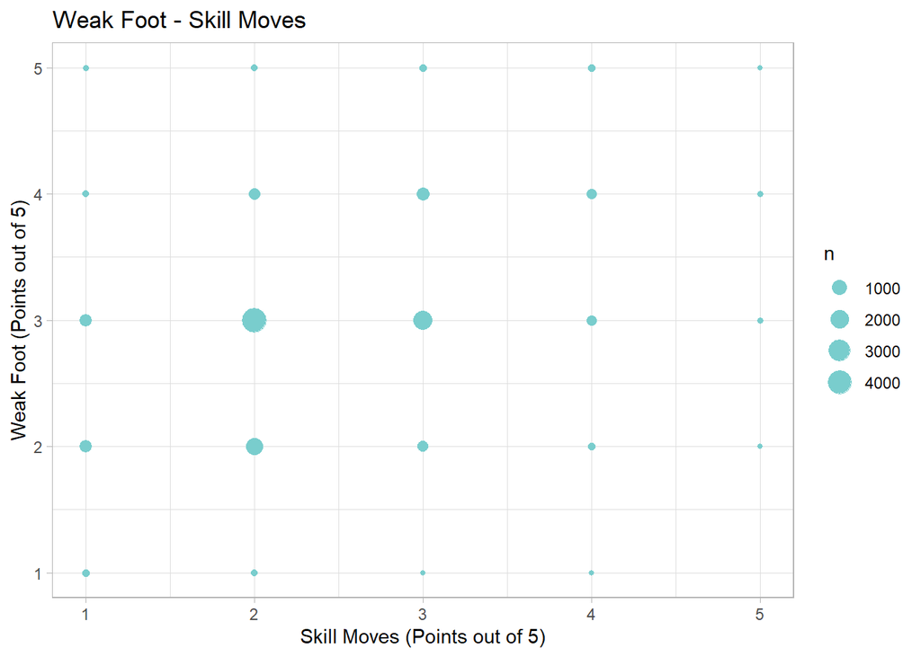

```r
ggplot(dataset, aes(dataset$Skill.Moves, dataset$Weak.Foot)) + geom_count(color = "darkslategray3") +
  labs(title = "Weak Foot - Skill Moves", x = "Skill Moves (Points out of 5)",
       y = "Weak Foot (Points out of 5)") + theme_light()
```

It is also interesting to see if the players that are tall maybe have a worst skill move compared to the smallest players, that may have more control at the ball and be able to dribble better

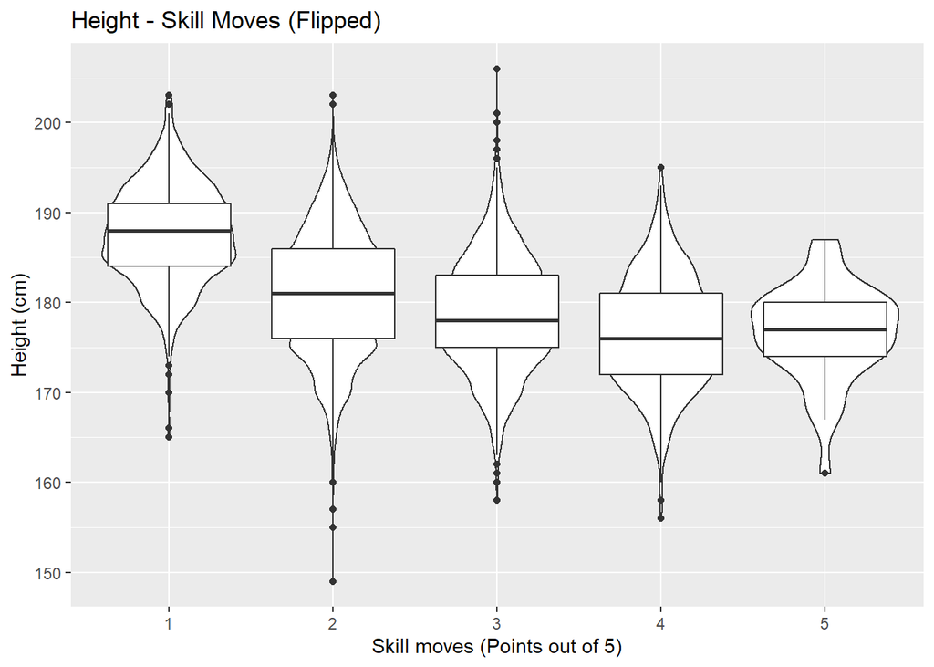

```r
ggplot(dataset, aes(as.factor(dataset$Skill.Moves), dataset$Height)) +
  geom_violin() + geom_boxplot() + labs(title = "Height - Skill Moves (Flipped)",
                                        x= "Skill moves (Points out of 5)",
                                        y = "Height (cm)")
```

It is true that the footballers with the best skill moves are quite smaller that are around 177 cm compared to the players with the worst skill moves that tends the 190 cm.

Also, despite there are too much countries to have a visual result, I was quite interested in knowing if the nationality could have an impact on the international reputation of the players.

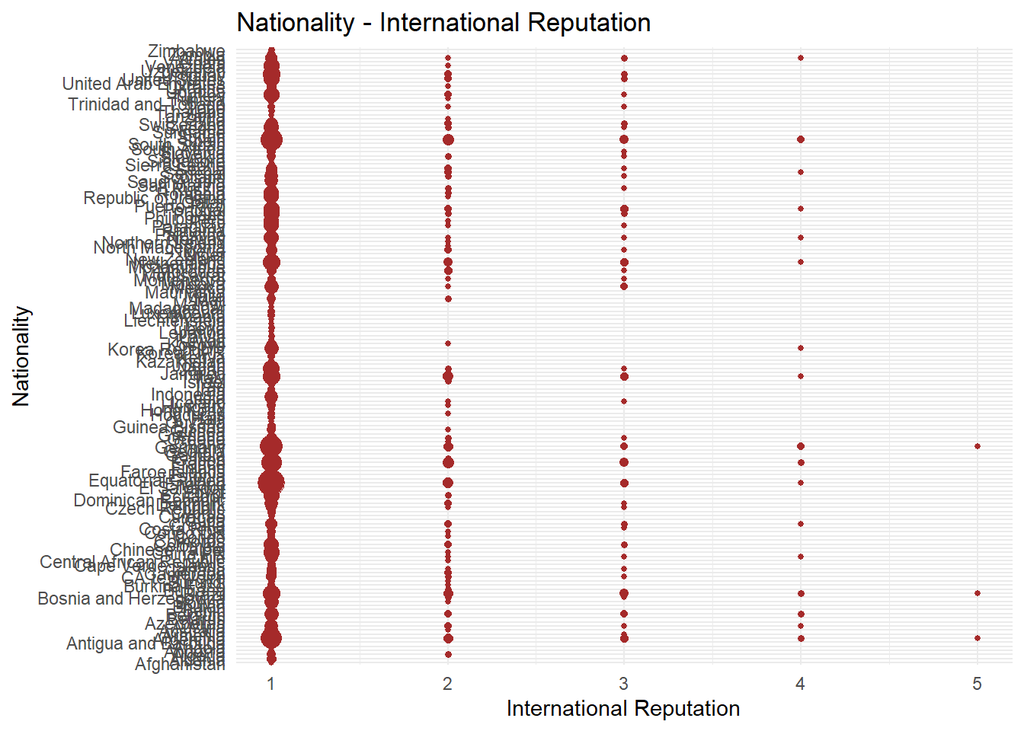

```r
ggplot(dataset, aes(as.factor(dataset$Nationality), as.numeric(dataset$International.Reputation))) + geom_count(color = "brown") +
  labs(title = "Nationality - International Reputation", x = "Nationality",
       y = "International Reputation") + theme_minimal() + coord_flip() +
  theme(legend.position = "none") + scale_x_discrete()
```

After analyzing the result, there is plenty of evidence that it could really have an impact that depending on the country a footballer could have a higher or lower international reputation. (Furthermore, with the current political situation, it makes sense)

It could be interesting to compare between the work rate and the value of the players, in order to know to what extend this variable has an impact on the players value.

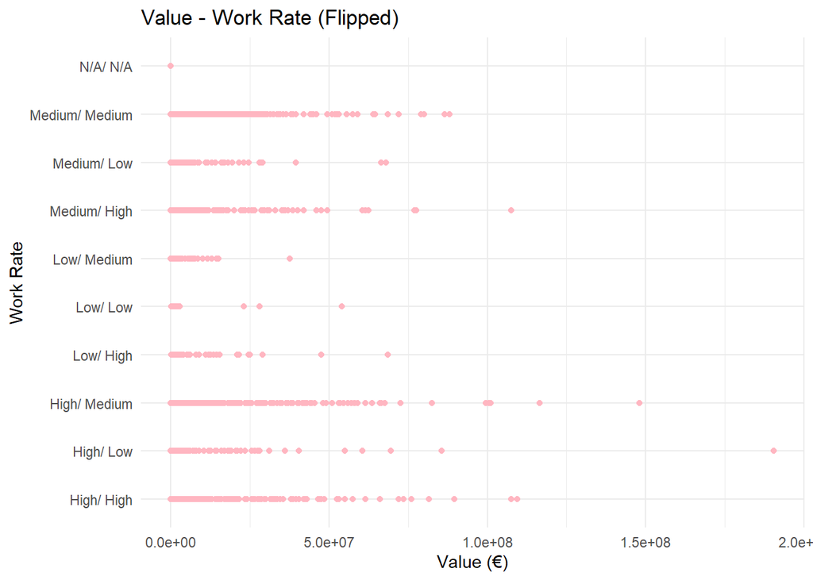

```r
ggplot(dataset, aes(dataset$Work.Rate, dataset$Value)) +
  geom_point(color = "lightpink") + coord_flip() +
  labs(title = "Value - Work Rate (Flipped)", y = "Value (€)", x = "Work Rate") +
  theme_minimal()
```

We can notice there are some differences specially with the players with the low work rate.

We can also compare the player’s release clause and his value in the market in order to see if this both variables increases at the same time equally

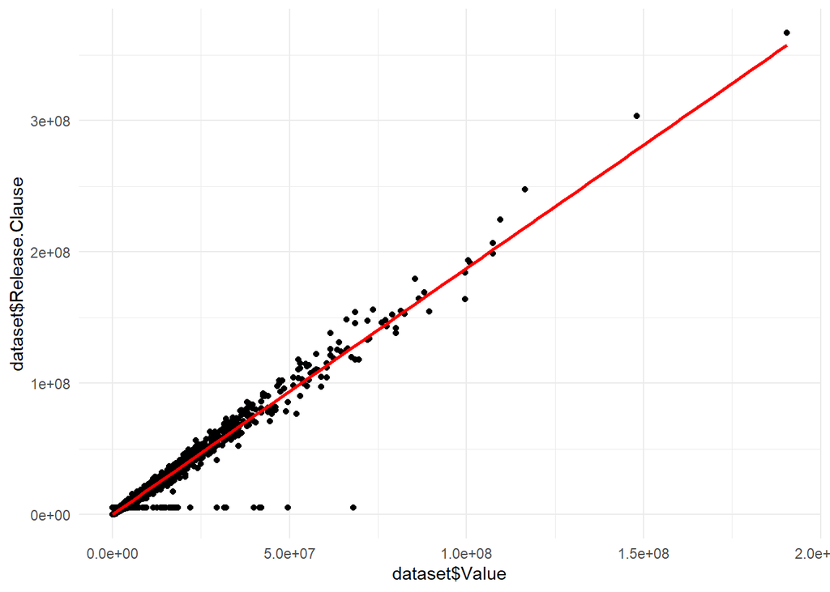

```r
ggplot(dataset, aes(dataset$Value, dataset$Release.Clause)) + geom_point() +
  geom_smooth(color = "red", method = "gam", formula = y ~ x) + theme_minimal()
```

As we can see, there is a strong positive relation ship between this two variables, it looks like they are directly proportional.

After visualizing different variables, lets focus on our main target variables (numeric and categorical)

We could compare our main categorical and numerical variables in order to see their relation

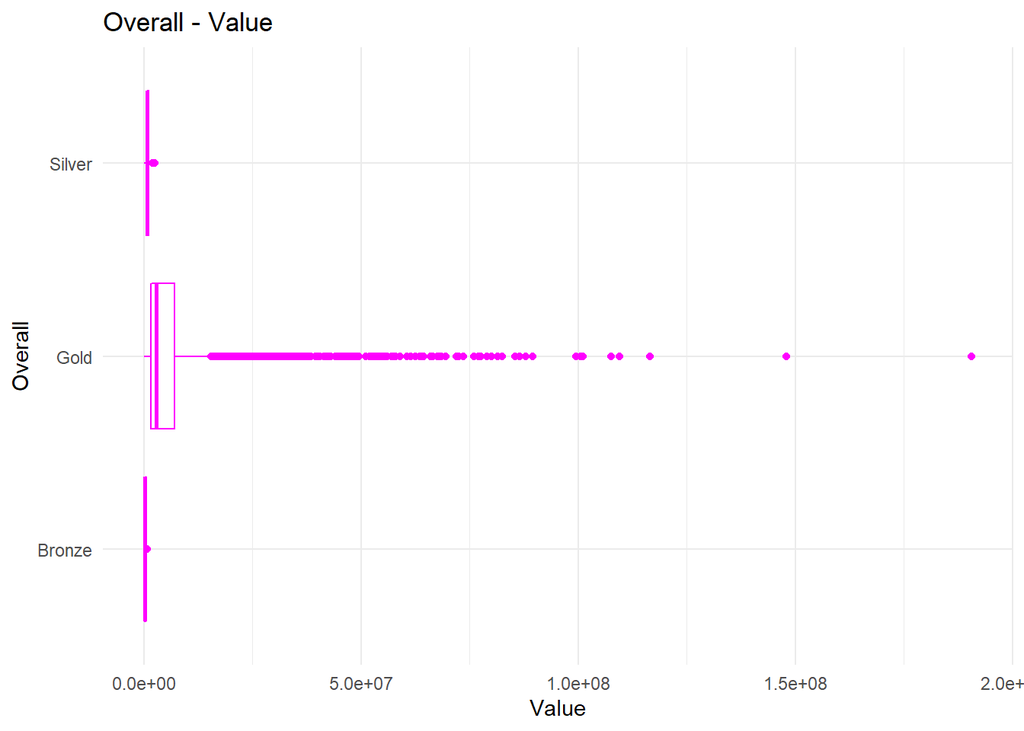

```r
ggplot(dataset, aes(dataset$Type, dataset$Value)) + geom_boxplot(color = "magenta") +
    labs(title = "Overall - Value", x = "Overall",
         y = "Value") + theme_minimal() + coord_flip() + scale_alpha()
```

It is clear that the footballers that belongs to the gold category have the highest value in the market, which makes sense because the gold players are the players with the best overall between the three categories in this variable in the game so it is common to think that those are the players with the highest value.

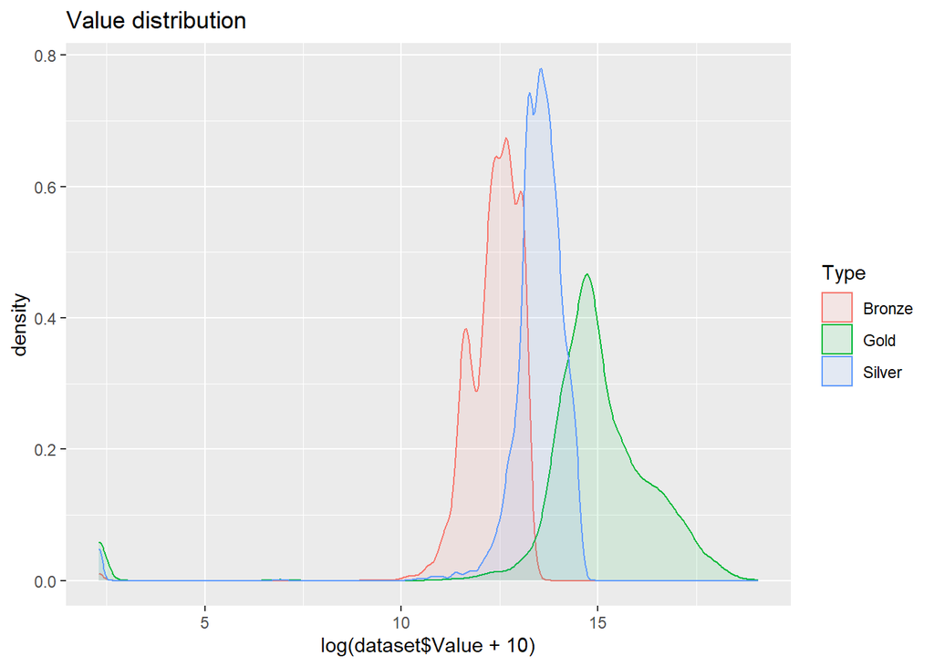

```r
ggplot(dataset, aes(log(dataset$Value+10))) + geom_density(aes(group=Type, colour=Type, fill=Type), alpha=0.1) +
  ggtitle("Value distribution")
```

Now we could see the relation between the value variable with the rest of the numerical variables,

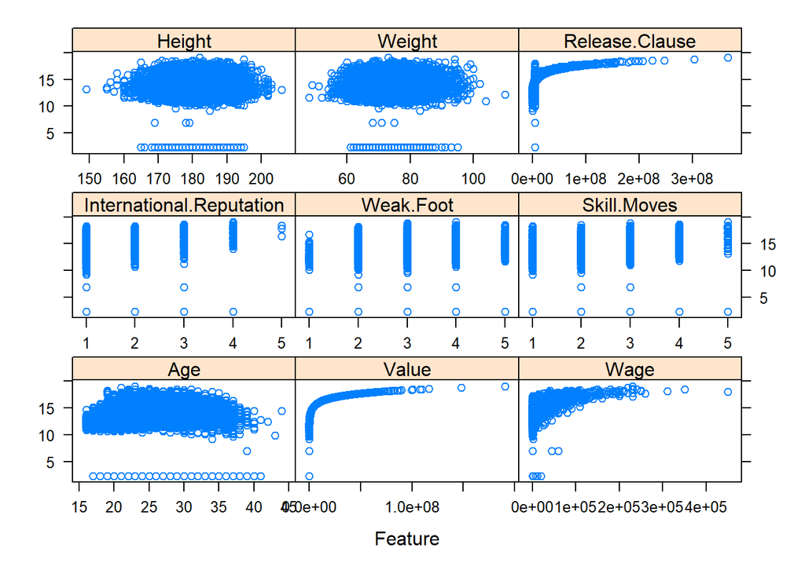

```r
# We get a data set with just the numeric variables

value_dataset = dataset

value_dataset$Name = NULL
value_dataset$Nationality = NULL
value_dataset$Preferred.Foot = NULL
value_dataset$Work.Rate = NULL
value_dataset$Real.Face = NULL
value_dataset$Club = NULL
value_dataset$Type = NULL

featurePlot(x =value_dataset[, c(1:9)],
            y = log(dataset$Value+10),
            plot = "scatter",
            layout = c(3,3))
```

Thanks to this graphical analysis, we found the distribution of different variables of different classes (factor, numerical…) and also the relationship between different variables and we can understand easily our target variables (and also the other ones)

# CLASSIFICATION

**NOTE:** It is important to mention that in order to apply all the methods, I will use an auxiliar variable called “aux” which will be identical to the original data set in order to have my original data set save.

```r
# Variable aux in order to save the original main data set
aux = dataset

#Lets delete some variables that can cause some issues when applying LDA because this proccess must make an analysis for all this characters variables, so the variables which contains a lot of groups (such as names or nationalities) must be removed
dataset$Name = NULL
dataset$Nationality = NULL
dataset$Club = NULL


spl = createDataPartition(dataset$Type, p = 0.8, list = FALSE)  # 80% for training

datasetTrain = dataset[spl,]
datasetTest = dataset[-spl,]

table(datasetTrain$Type)
```

```
##
## Bronze   Gold Silver
##   3048   2968   3146
```

```r
table(datasetTest$Type)
```

```
##
## Bronze   Gold Silver
##    762    741    786
```

Lets see if the classes are balanced

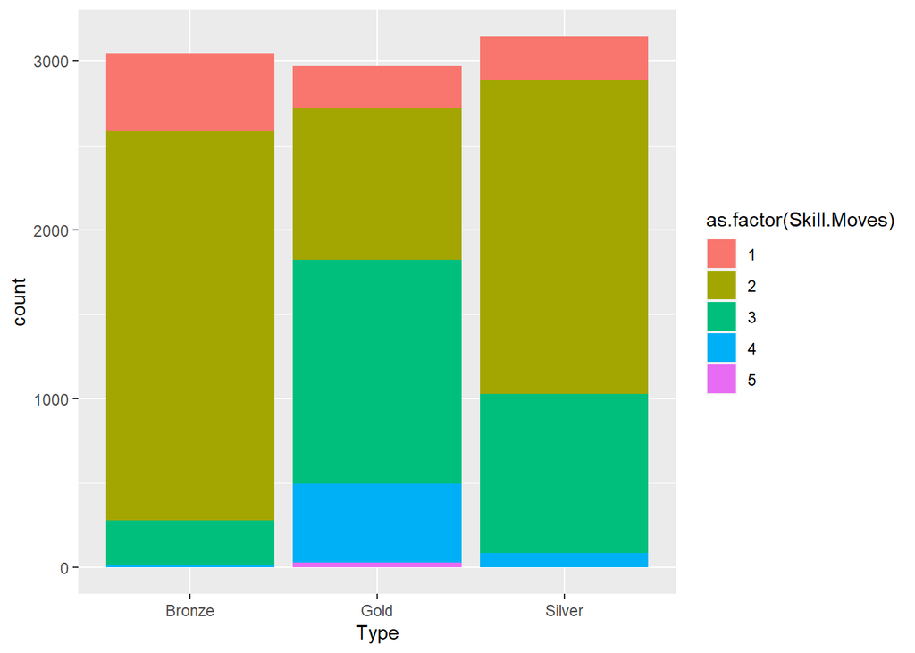

```r
ggplot(datasetTrain, aes(x=Type, fill = as.factor(Skill.Moves))) + geom_bar()
```

It is easy to think that players in the gold category will have better skill moves compared to the other categories which have worst players, and this logic can also be translated to players that are in the silver category which should have better skill moves rather than players in the bronze class.

# Bayes Classifiers

## LDA

Lets start creating our lda model by using our target categorical variable (Overall)

```r
lda.model <- lda(Type ~ ., data=datasetTrain,  prior = c(1/3, 1/3, 1/3))

# Alternative way that I found searching by my own:
# lda.model <- lda(datasetTrain[,-16], grouping = datasetTrain[,16], prior = c(1/6, 1/3, 1/2))

lda.model
```

```
## Call:
## lda(Type ~ ., data = datasetTrain, prior = c(1/3, 1/3, 1/3))
##
## Prior probabilities of groups:
##    Bronze      Gold    Silver
## 0.3333333 0.3333333 0.3333333
##
## Group means:
##             Age     Value      Wage Preferred.FootRight
## Bronze 19.97277  272746.1  1062.336           0.8120079
## Gold   26.55222 7366948.1 22284.181           0.7503369
## Silver 22.87762  833468.2  1903.401           0.7660521
##        International.Reputation Weak.Foot Skill.Moves Work.RateHigh/ Low
## Bronze                 1.000984  2.718504    1.943898         0.02657480
## Gold                   1.319070  3.116577    2.707210         0.04919137
## Silver                 1.005404  2.869676    2.271774         0.03909727
##        Work.RateHigh/ Medium Work.RateLow/ High Work.RateLow/ Low
## Bronze             0.1092520         0.01279528       0.007874016
## Gold               0.2486523         0.02324798       0.003369272
## Silver             0.1846790         0.02511125       0.003814367
##        Work.RateLow/ Medium Work.RateMedium/ High Work.RateMedium/ Low
## Bronze           0.02329396            0.04625984           0.04166667
## Gold             0.01954178            0.11623989           0.04716981
## Silver           0.02193261            0.08010172           0.04195804
##        Work.RateMedium/ Medium Work.RateN/A/ N/A Real.FaceTRUE   Height
## Bronze               0.7188320       0.001968504    0.00164042 180.7392
## Gold                 0.3911725       0.007412399    0.32378706 181.4518
## Silver               0.5692943       0.002860776    0.02511125 180.4437
##          Weight Release.Clause
## Bronze 73.23458       676924.9
## Gold   75.69070     13914764.4
## Silver 74.01589      1915032.3
##
## Coefficients of linear discriminants:
##                                    LD1           LD2
## Age                       1.850720e-01  1.303220e-01
## Value                     2.849027e-08 -3.098757e-08
## Wage                      1.100708e-05 -3.359009e-05
## Preferred.FootRight      -1.300890e-01 -2.547372e-01
## International.Reputation -6.321934e-01 -8.063909e-01
## Weak.Foot                 1.658224e-01  8.990564e-02
## Skill.Moves               6.510999e-01  4.496974e-01
## Work.RateHigh/ Low       -4.685260e-01  4.427392e-02
## Work.RateHigh/ Medium    -2.949246e-01  4.211691e-01
## Work.RateLow/ High       -5.328998e-01  1.005706e+00
## Work.RateLow/ Low        -1.283894e+00 -3.108963e-01
## Work.RateLow/ Medium     -6.185805e-01  3.059330e-01
## Work.RateMedium/ High    -1.761640e-01  4.045554e-01
## Work.RateMedium/ Low     -6.723476e-01 -1.035856e-01
## Work.RateMedium/ Medium  -5.941863e-01  1.462685e-01
## Work.RateN/A/ N/A         7.115411e-01 -4.045020e-01
## Real.FaceTRUE             8.460650e-01 -1.434432e+00
## Height                    1.921304e-02 -1.671275e-02
## Weight                    1.608089e-02  2.057431e-02
## Release.Clause            1.857966e-09  3.115150e-08
##
## Proportion of trace:
##    LD1    LD2
## 0.9467 0.0533
```

Note there are two linear classifiers because we have 3 classes. Its important to mention that in our case, because our data set is more or less balanced, our prior can be equal an divided by the number of classes (in our case 3 classes). But prior should represent the proportion of each class

Lets compute the posterior probabilities

```r
probability = predict(lda.model, newdata=datasetTest)$posterior
head(probability)
```

```
##          Bronze      Gold       Silver
## 12 3.672981e-06 0.9999864 9.916151e-06
## 27 3.740223e-05 0.9985498 1.412800e-03
## 29 1.749824e-04 0.9986869 1.138111e-03
## 33 3.451246e-05 0.9972357 2.729763e-03
## 54 9.290970e-04 0.9936757 5.395183e-03
## 55 2.288915e-04 0.9946834 5.087727e-03
```

We can predict the labels for the type variable, by applying the Bayes rules of maximum probability

```r
prediction <- max.col(probability)

head(prediction)
```

```
## [1] 2 2 2 2 2 2
```

We can see that the prediction obtained more or less balanced classes. However, just by looking at it and comparing with what we know are the true values of the data set, we can see there are some important mistakes, so we could expect the accuracy would be around 60%.

An alternative way in which instead of representing the number of the class, the output is the name of the class predicted.

```r
prediction = predict(lda.model, newdata=datasetTest)$class

head(prediction)
```

```
## [1] Gold Gold Gold Gold Gold Gold
## Levels: Bronze Gold Silver
```

```r
summary(prediction)
```

```
## Bronze   Gold Silver
##    902    583    804
```

Performance:

Lets start by computing the confusion matrix

```r
table(prediction, datasetTest$Type)
```

```
##
## prediction Bronze Gold Silver
##     Bronze    599   43    260
##     Gold        9  477     97
##     Silver    154  221    429
```

```r
confusionMatrix(prediction, datasetTest$Type)$table
```

```
##           Reference
## Prediction Bronze Gold Silver
##     Bronze    599   43    260
##     Gold        9  477     97
##     Silver    154  221    429
```

```r
confusionMatrix(prediction, datasetTest$Type)$overall[1]
```

```
##  Accuracy
## 0.6574924
```

As we can see, we obtain the accuracy of the model, which is around 65% of accuracy. It is not a very good model but is not too bad either, probably we obtained a decent accuracy because our classes are quite balanced, which is quite important. The result was quite expected just by looking when previously we used the function summary() in order to see prediction. However, in order to improve even more this accuracy and especially for the cases in which we have unbalanced classes, a good idea is to instead of having 3 classes, create just two classes in order to have the most balanced set as possible, in my case, it is not too necessary, however, later on I will apply this same method with just two classes in order to see if we obtain a better accuracy or not. Anyways, the accuracy obtained with this model was quite good.

## QDA

```r
qda.model <- qda(Type ~ ., data=datasetTrain, prior = c(1/3, 1/3, 1/3))
qda.model
```

```
## Call:
## qda(Type ~ ., data = datasetTrain, prior = c(1/3, 1/3, 1/3))
##
## Prior probabilities of groups:
##    Bronze      Gold    Silver
## 0.3333333 0.3333333 0.3333333
##
## Group means:
##             Age     Value      Wage Preferred.FootRight
## Bronze 19.97277  272746.1  1062.336           0.8120079
## Gold   26.55222 7366948.1 22284.181           0.7503369
## Silver 22.87762  833468.2  1903.401           0.7660521
##        International.Reputation Weak.Foot Skill.Moves Work.RateHigh/ Low
## Bronze                 1.000984  2.718504    1.943898         0.02657480
## Gold                   1.319070  3.116577    2.707210         0.04919137
## Silver                 1.005404  2.869676    2.271774         0.03909727
##        Work.RateHigh/ Medium Work.RateLow/ High Work.RateLow/ Low
## Bronze             0.1092520         0.01279528       0.007874016
## Gold               0.2486523         0.02324798       0.003369272
## Silver             0.1846790         0.02511125       0.003814367
##        Work.RateLow/ Medium Work.RateMedium/ High Work.RateMedium/ Low
## Bronze           0.02329396            0.04625984           0.04166667
## Gold             0.01954178            0.11623989           0.04716981
## Silver           0.02193261            0.08010172           0.04195804
##        Work.RateMedium/ Medium Work.RateN/A/ N/A Real.FaceTRUE   Height
## Bronze               0.7188320       0.001968504    0.00164042 180.7392
## Gold                 0.3911725       0.007412399    0.32378706 181.4518
## Silver               0.5692943       0.002860776    0.02511125 180.4437
##          Weight Release.Clause
## Bronze 73.23458       676924.9
## Gold   75.69070     13914764.4
## Silver 74.01589      1915032.3
```

Now we can study the performance of the model and find its accuracy.

```r
prediction = predict(qda.model, newdata=datasetTest)$class
confusionMatrix(prediction, datasetTest$Type)$table
```

```
##           Reference
## Prediction Bronze Gold Silver
##     Bronze    709    1    204
##     Gold        5  564     44
##     Silver     48  176    538
```

```r
confusionMatrix(prediction, datasetTest$Type)$overall[1]
```

```
##  Accuracy
## 0.7911752
```

## Benchmark model

```r
obs <- max(table(datasetTest$Type))

#Accuracy
obs/nrow(datasetTest) #0.3
```

```
## [1] 0.3433814
```

As we can see the benchmark is not very good, probably because there are too many noise.

One idea in order to improve our accuracy (or reduce our noise) would be to if instead of considering 3 classes, we transform it into only two classes (for example, “Elite” and “Average”). However, that would imply that our data set will be less practical because at the end of the day our objective is try to predict if a player belongs to one of the already existing categories in FIFA 23 (Gold, silver, bronze).  
As I explained previously, in my case it would not be extremely necessary because it is not worth it to obtain a less practical response variable for just obtaining balanced groups in order to avoid noise, because in our case the groups are already quite balanced.

Because the groups will be more balanced, that would probably imply an increase in the accuracy of the model.

As I said before, I saved a variable called “dataset_2c” in order to save the dataset with the variable Overall in numerical terms

```r
# We will save again our original data set with the categorical variable (Overall) still like a numerical variable
copy = dataset_2c
```

```r
dataset_2c$Type = factor(ifelse(dataset_2c$Overall <= 62, "Average", "Elite"))
# We must delete the Overall class
dataset_2c$Overall = NULL

# We finally convert the Overall variable into a factor by using the function as.factor() to finally transform it from a numerical to a categorical variable
dataset_2c$Type= as.factor(dataset_2c$Type)
```

Lets see the classes and how many rows are in each class

```r
levels(dataset_2c$Type)
```

```
## [1] "Average" "Elite"
```

```r
table(dataset_2c$Type)
```

```
##
## Average   Elite
##    5617    5834
```

As before, we must apply the same procedure.

```r
dataset_2c$Name = NULL
dataset_2c$Nationality = NULL
dataset_2c$Club = NULL
```

Again, we split the data into train and test sets.

```r
spl_2c = createDataPartition(dataset_2c$Type, p = 0.8, list = FALSE)  # 80% for training

datasetTrain_2c = dataset_2c[spl_2c,]
datasetTest_2c = dataset_2c[-spl_2c,]

table(datasetTrain_2c$Type)
```

```
##
## Average   Elite
##    4494    4668
```

Now it is much more balanced the classes in the training and test set too.

```r
lda.model <- lda(Type ~ ., data= datasetTrain_2c)
prediction = predict(lda.model, newdata= datasetTest_2c)$class
confusionMatrix(prediction, datasetTest_2c$Type)$table
```

```
##           Reference
## Prediction Average Elite
##    Average     966   294
##    Elite       157   872
```

```r
confusionMatrix(prediction, datasetTest_2c$Type)$overall[1]
```

```
##  Accuracy
## 0.8029707
```

## Logistic regression

For logistic regression is focused on binary classification (however, there exist some algorithms in order to solve 3-class classification tasks). However, for my case, I will use my 2-class set to apply logistic regression, in that way I could apply the glm function in R.

```r
aux_2c = dataset_2c
auxtrain_2c = datasetTrain_2c
auxtest_2c = datasetTest_2c

# We should remove from the training and test sets the non-numerical variables in order to apply this tool. However, it is not necessary  because R does it automatically.
auxtrain_2c$Preferred.Foot = NULL
auxtrain_2c$Work.Rate = NULL
auxtrain_2c$Real.Face = NULL
auxtrain_2c$Preferred.Foot = NULL
auxtrain_2c$Work.Rate = NULL
auxtrain_2c$Real.Face = NULL

logit.model <- glm(Type ~ ., family=binomial(link='logit'), data= datasetTrain_2c)
summary(logit.model)
```

```
##
## Call:
## glm(formula = Type ~ ., family = binomial(link = "logit"), data = datasetTrain_2c)
##
## Deviance Residuals:
##     Min       1Q   Median       3Q      Max
## -4.6605  -0.0573   0.0000   0.0035   3.8566
##
## Coefficients:
##                            Estimate Std. Error z value Pr(>|z|)
## (Intercept)              -4.034e+01  3.870e+02  -0.104  0.91698
## Age                       7.555e-01  2.667e-02  28.332  < 2e-16 ***
## Value                     9.825e-06  3.463e-07  28.368  < 2e-16 ***
## Wage                     -1.575e-04  3.470e-05  -4.538 5.67e-06 ***
## Preferred.FootRight       1.577e-02  1.377e-01   0.115  0.90878
## International.Reputation  1.518e+01  3.870e+02   0.039  0.96872
## Weak.Foot                 9.611e-03  9.722e-02   0.099  0.92125
## Skill.Moves               4.020e-02  1.074e-01   0.374  0.70812
## Work.RateHigh/ Low       -2.321e-01  4.568e-01  -0.508  0.61139
## Work.RateHigh/ Medium    -1.029e+00  3.813e-01  -2.698  0.00698 **
## Work.RateLow/ High       -4.731e-01  5.449e-01  -0.868  0.38527
## Work.RateLow/ Low        -2.892e+00  1.765e+00  -1.639  0.10124
## Work.RateLow/ Medium     -6.726e-01  5.129e-01  -1.311  0.18973
## Work.RateMedium/ High    -7.065e-01  4.083e-01  -1.730  0.08356 .
## Work.RateMedium/ Low     -9.020e-01  4.655e-01  -1.938  0.05266 .
## Work.RateMedium/ Medium  -1.030e+00  3.645e-01  -2.825  0.00473 **
## Work.RateN/A/ N/A         1.949e+00  1.161e+00   1.679  0.09316 .
## Real.FaceTRUE             1.772e-01  4.532e-01   0.391  0.69580
## Height                   -1.960e-03  1.307e-02  -0.150  0.88079
## Weight                    5.774e-03  1.369e-02   0.422  0.67309
## Release.Clause            7.886e-07  5.221e-08  15.104  < 2e-16 ***
## ---
## Signif. codes:  0 '***' 0.001 '**' 0.01 '*' 0.05 '.' 0.1 ' ' 1
##
## (Dispersion parameter for binomial family taken to be 1)
##
##     Null deviance: 12697.9  on 9161  degrees of freedom
## Residual deviance:  1973.4  on 9141  degrees of freedom
## AIC: 2015.4
##
## Number of Fisher Scoring iterations: 21
```

Make predictions (posterior probabilities):

```r
probability <- predict(logit.model,newdata=datasetTest_2c, type='response')
head(probability)
```

```
## 14 18 21 29 31 33
##  1  1  1  1  1  1
```

```r
summary(probability)
```

```
##      Min.   1st Qu.    Median      Mean   3rd Qu.      Max.
## 0.0000005 0.0019042 0.5339927 0.5069054 0.9999966 1.0000000
```

We might better use the function summary() instead of the head() function because as my data set is organized by the players that had the best overall to the players with the worst overall, it seems that the predictions are wrong.

```r
prediction <- as.factor(ifelse(probability > 0.5,"Elite","Average"))
head(prediction)
```

```
##    14    18    21    29    31    33
## Elite Elite Elite Elite Elite Elite
## Levels: Average Elite
```

```r
summary(prediction)
```

```
## Average   Elite
##    1133    1156
```

Now lets compute the confusion matrix and analyze its performance in order to see the accuracy

```r
confusionMatrix(prediction, datasetTest_2c$Type)
```

```
## Confusion Matrix and Statistics
##
##           Reference
## Prediction Average Elite
##    Average    1082    51
##    Elite        41  1115
##
##                Accuracy : 0.9598
##                  95% CI : (0.9509, 0.9675)
##     No Information Rate : 0.5094
##     P-Value [Acc > NIR] : <2e-16
##
##                   Kappa : 0.9196
##
##  Mcnemar's Test P-Value : 0.3481
##
##             Sensitivity : 0.9635
##             Specificity : 0.9563
##          Pos Pred Value : 0.9550
##          Neg Pred Value : 0.9645
##              Prevalence : 0.4906
##          Detection Rate : 0.4727
##    Detection Prevalence : 0.4950
##       Balanced Accuracy : 0.9599
##
##        'Positive' Class : Average
##
```

As we can see, we obtained a high accuracy (95% more or less) and also a high kappa. By looking at the confusion matrix we can visually notice that our model has been quite accurate. At the moment is one of our best models plotted.